# Simutation

A組：李泓哲、葉嘉浤、劉柏均、黃科銓、陳泯宏、朱信榮、翁瑋廷、陳宏丞、許祐誠

2020/12/13

# MLE是什麼？

畫出在不同theta值下的likelihood,找出max likelihood 所對應的theta值。
$$L(\theta;x)=\prod^n_{i=1}f(x_i;\theta)=\big(\frac{1}{\sqrt{2\pi}}\big)^n e^{-\frac{(x_i-\theta)^2}{2}}$$

以N(mu,1)、N(0,sigma^2)、Exp(rate)來說明MLE

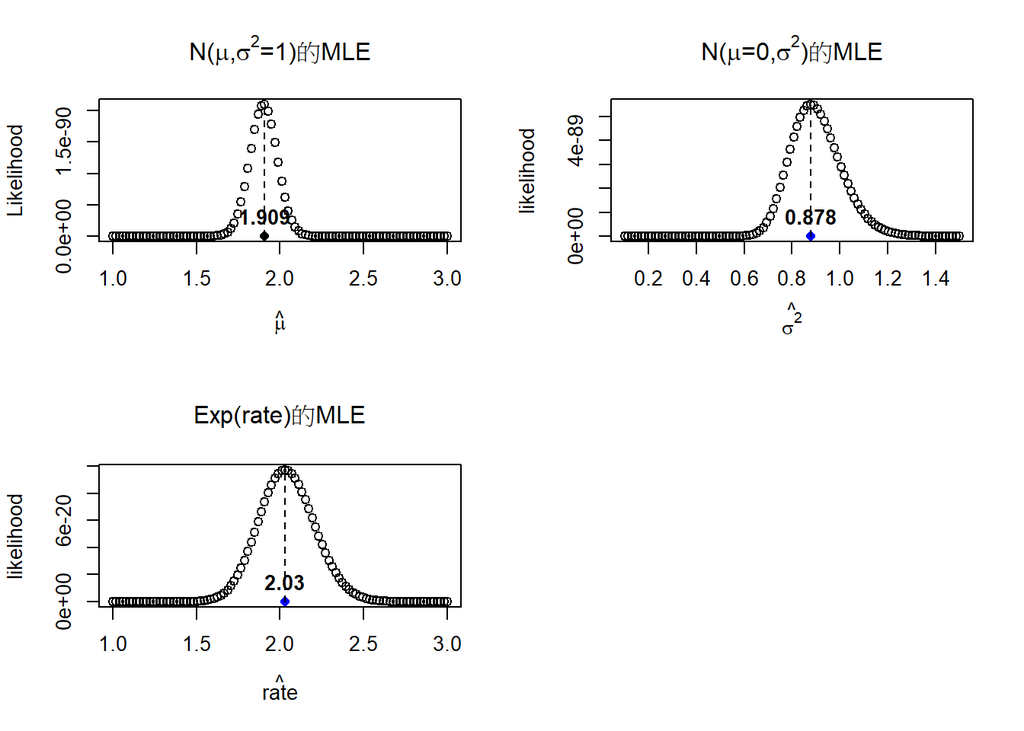

```r
par(mfrow=c(2,2))
set.seed(1234)

###N(mu,1)##
#set the parameter
B<-100
n<-150
mu<-2
sigma1<-1 #sd

#set the likelihood function and range
L<-function(x_bar, x, sigma0=sigma1) prod( dnorm(x, mean=x_bar, sd=sigma0) ) #Likelihood
theta.hat<-seq(1, 3, length.out = B) #set the range to search MLE

#1.Find  MLE.
Xn<-rnorm(n, mean=mu, sd=sigma1)
l<-c()
for (i in 1:B){
  l[i]<-L(theta.hat[i],Xn)
}
MLE_Xn<-theta.hat[which.max(l)]
plot(theta.hat, l, ylab="Likelihood", xlab=expression(hat(mu)),main=expression(paste( "N(",mu,",",sigma^2,"=1)的MLE")))
points(MLE_Xn, 0, col=1, pch=16, cex=1)
text(MLE_Xn,0, labels=round(theta.hat[which.max(l)],3),font=2,pos=3)
lines(c(MLE_Xn,MLE_Xn),c(0,L(MLE_Xn,Xn)),lty=2,col=1)

#compare simlution MLE and theretical MLE
MLE_norm_mu_simlution<-theta.hat[which.max(l)]
MLE_norm_mu_theretical<-mean(Xn)

###N(1,sigma2)###
#set the parameter
B<-100
n<-150
mu<-1
sigma2<-0.81
#set the likelihood function and range
L<-function(s2, x, mu0=mu) prod(dnorm(x, mean=mu0, sd=sqrt(s2))) #likelyhood of var
theta.hat<-seq(0.1, 1.5, length.out = B) #set the range to search MLE

#1.Find MLE.
Xn<-rnorm(n, mean=mu, sd=sqrt(sigma2))
l<-c()
for (i in 1:B){
  l[i]<-L(theta.hat[i],Xn)
}
MLE_Xn<-theta.hat[which.max(l)]
plot(theta.hat, l, ylab="likelihood", xlab=expression(hat(sigma^2)),main=expression(paste("N(",mu,"=0,",sigma^2,")的MLE")))
points(MLE_Xn, 0, col=4, pch=16, cex=1)
text(MLE_Xn,0, labels=round(theta.hat[which.max(l)],3), col=1,cex=1, font=2,pos=3)
lines(c(MLE_Xn,MLE_Xn),c(0,L(MLE_Xn,Xn)),lty=2)

#compare simlution MLE and theretical MLE
MLE_norm_sigma_simlution<-theta.hat[which.max(l)]
MLE_norm_sigma_theretical<-var(Xn)*(n-1)/n

#set the parameter
B<-100
n<-150
rate<-2
#set the likelihood function and range
L<-function(r, x) prod( dexp(x,rate = r) ) #Likelyhood
theta.hat<-seq(1,3, length.out = B)#set the range to search MLE #rate !

### exp(rate)###
#1.Find  MLE.
Xn<-rexp(n,rate = rate)
l<-c()
for (i in 1:B){
  l[i]<-L(theta.hat[i],Xn)
}
MLE_Xn<-theta.hat[which.max(l)]
plot(theta.hat, l, ylab="likelihood", xlab=expression(hat(rate)),main=expression(paste("Exp(rate)的MLE")))
points(MLE_Xn, 0, col=4, pch=16, cex=1)
text(MLE_Xn,0, labels=round(theta.hat[which.max(l)],3), col=1,cex=1, font=2,pos=3)
lines(c(MLE_Xn,MLE_Xn),c(0,L(MLE_Xn,Xn)),lty=2)

#compare simlution MLE and theretical MLE
MLE_exp_rate_simlution<-theta.hat[which.max(l)]
MLE_exp_rate_theretical<-1/mean(Xn)
```

```r
Simulation<-c(MLE_norm_mu_simlution,MLE_norm_sigma_simlution,MLE_exp_rate_simlution)
Theretical<-c(MLE_norm_mu_theretical,MLE_norm_sigma_theretical,MLE_exp_rate_theretical)
data_all<-data.frame(Simulation,Theretical)
row.names(data_all)<-c("N($\\mu$,1)","N(0,$\\sigma^2$)","Exp(rate=$\\lambda$)")
knitr::kable(data_all,align = "ccc",caption = 'MLE的模擬值與理論值比較')
```

MLE的模擬值與理論值比較

|  | Simulation | Theretical |
| --- | --- | --- |
| N($\mu$,1) | 1.9090909 | 1.9021515 |
| N(0,$\sigma^2$) | 0.8777778 | 0.8672413 |
| Exp(rate=$\lambda$) | 2.0303030 | 2.0302169 |

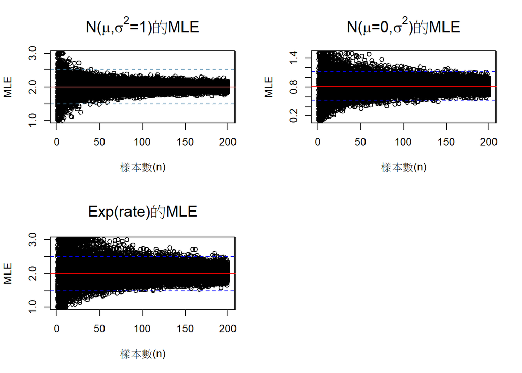

```r
par(mfrow=c(2,2))
set.seed(1234)
B<-100
n<-200

#N(mu,1)
mu<-2
sigma1<-1 #sd
L<-function(x_bar, x, sigma0=sigma1) prod( dnorm(x, mean=x_bar, sd=sigma0) ) #Likelihood
theta.hat<-seq(1, 3, length.out = B) #set the range to search MLE
MLE_data<-matrix(NA, B,n)

for (i in 1:n){
  N_data<-matrix(rnorm(B*i,mean=mu,sd=sigma1), B, i) #generate sample with size n and repeat B
  for ( j in 1:B){        #find MLE in each B times
    likehood<-lapply(theta.hat,function(s) L(x_bar=s,x=N_data[j,]))
    MLE<-theta.hat[which.max(likehood)]
    MLE_data[j,i]<-MLE
  }
}
x<-rep(1:n, each=B)
y<-c(MLE_data)
plot(y~jitter(x,0.1), ylab=expression("MLE"), xlab="樣本數(n)",main=expression(paste( "N(",mu,",",sigma^2,"=1)的MLE")),cex.main=1.5)
epsilon<-0.5
abline(h=mu, col="#ed6663")
abline(h=mu+epsilon, col="#4e89ae", lty=2)
abline(h=mu-epsilon, col="#4e89ae", lty=2)

#N(0,sigma2)
mu<-1
sigma2<-0.81
L<-function(s2, x, mu0=mu) prod(dnorm(x, mean=mu0, sd=sqrt(s2))) #likelyhood of var
theta.hat<-seq(0.1, 1.5, length.out = B) #set the range to search MLE
MLE_data<-matrix(NA, B,n)

for (i in 1:n){
  N_data<-matrix(rnorm(B*i, mean=mu, sd=sqrt(sigma2)), B, i) #generate sample with size n and repeat B
  for ( j in 1:B){ #find MLE in each B times
    likehood<-lapply(theta.hat,function(s2) L(s2,x=N_data[j,]))
    MLE<-theta.hat[which.max(likehood)]
    MLE_data[j,i]<-MLE
  }
}
x<-rep(1:n, each=B)
y<-c(MLE_data)
plot(y~jitter(x,0.1), ylab=expression("MLE"), xlab="樣本數(n)",main=expression(paste("N(",mu,"=0,",sigma^2,")的MLE")),cex.main=1.5)
epsilon<-0.3
abline(h=sigma2, col=2)
abline(h=sigma2+epsilon, col=4, lty=2)
abline(h=sigma2-epsilon, col=4, lty=2)

#exp(rate)
rate<-2
L<-function(r, x) prod( dexp(x,rate = r) ) #Likelyhood
theta.hat<-seq(1,3, length.out = B)#set the range to search MLE #rate !

MLE_data<-matrix(NA, B,n)
for (i in 1:n){
  N_data<-matrix(rexp(B*i,rate =rate ), B, i) #generate sample with size n and repeat B
  for ( j in 1:B){ #Find MLE in each time(total: B times)
    likehood<-lapply(theta.hat,function(r) L(r,x=N_data[j,]))
    MLE<-theta.hat[which.max(likehood)]
    MLE_data[j,i]<-MLE
  }
}
x<-rep(1:n, each=B)
y<-c(MLE_data)
plot(y~jitter(x,0.1), ylab=expression("MLE"), xlab="樣本數(n)",main=expression(paste("Exp(rate)的MLE")),cex.main=1.5)
epsilon<-0.5
abline(h=rate, col=2)
abline(h=rate+epsilon, col=4, lty=2)
abline(h=rate-epsilon, col=4, lty=2)
```

# Likelihood Ratio Test

我們先將 Likelihood Ratio 寫成
$$\Lambda(\theta)=\frac{L(\theta)}{L(\hat\theta)}$$
,再將取log後的 Log Likelihood Ratio 寫成
$$log\Lambda(\theta)=log\bigg(\frac{L(\theta)}{L(\hat\theta)}\bigg)=log\,L(\theta)-log\,L(\hat\theta)=l(\theta)-l(\hat\theta)$$
因此可以得到 Likelihood Ratio Test 的檢定統計量
$$\chi^2_L=-2llr(\theta)=-2\{l(\theta)-l(\hat\theta)\}$$
當$Under\, H_0$時，可以使$llr(\theta)$極大，可得到
$$\text{max}_{H_0}[l(\theta)]-\text{max}_{H_1}[l(\theta)]=l(\theta_0) - l(\hat\theta)=log\Lambda(\theta_0)$$
,因此
$$\text{Under }H_0\,,\quad \chi^2_L=-2log\Lambda(\theta_0)=-2\{l(\theta_0)-l(\hat\theta)\}\sim\chi^2_1$$

## Normal Distribution N(mu,1)

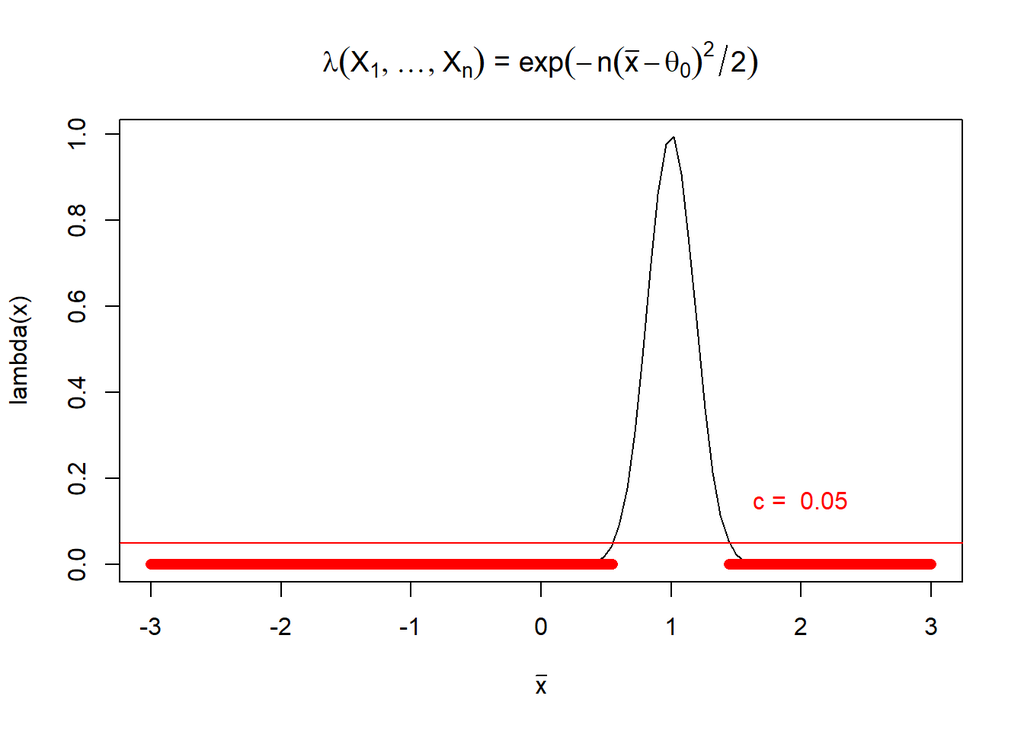

```r
#normal(theta,1)
c<-0.05
lambda<-function(xbar, theta0=1, n=30) exp(-n*(xbar-theta0)^2/2) # LRT statistic
curve(lambda, from=-3, to=3, xlab=expression(bar(x)), main=expression(paste(lambda(X[1],...,X[n])," = ", exp(-n(bar(x)-theta[0])^2/2))) )
abline(h=c, col=2)
text(2, c+0.1, paste("c = ", c), col=2)
RR<-seq(-3, 3, 0.01)[lambda(seq(-3, 3, 0.01) )< c]
points(RR, rep(0, length(RR)), col=2, pch=16 )
```

normal(theta,1)之下lambda的分配圖形，在不同的樣本數之下的趨勢改變

normal(theta,1)，在不同的樣本數下，將各lambda取-2log後，皆會服從卡方分配

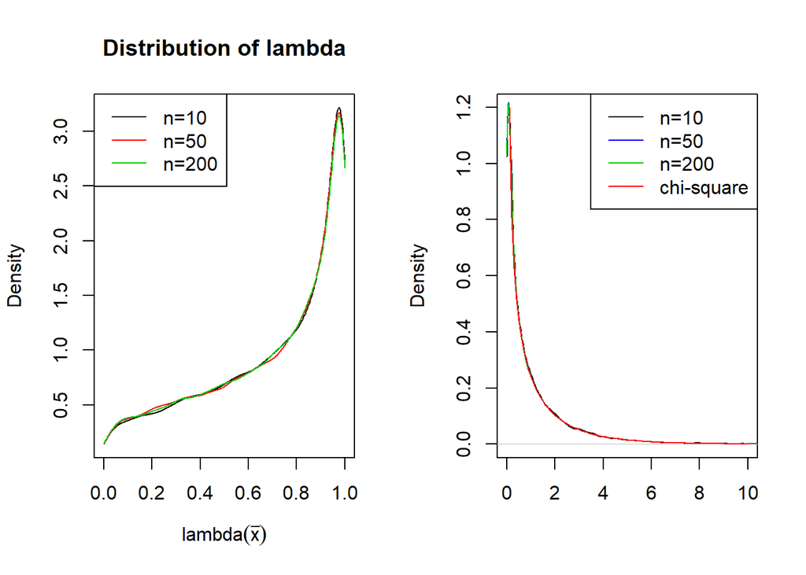

```r
par(mfrow=c(1,2))
#distribution of lambda
#theta0<-1
B<-30000
n1<-10;n2<-50;n3<-200
theta0<-1
lambda1<-c();lambda2<-c();lambda3<-c()
for (i in 1:B){
 x1<-rnorm(n1, mean = theta0, sd=1)
 xbar1<-mean(x1)
 lambda1[i]<-exp(-n1*(xbar1-theta0)^2/2)
 x2<-rnorm(n2, mean = theta0, sd=1)
 xbar2<-mean(x2)
 lambda2[i]<-exp(-n2*(xbar2-theta0)^2/2)
 x3<-rnorm(n3, mean = theta0, sd=1)
 xbar3<-mean(x3)
 lambda3[i]<-exp(-n3*(xbar3-theta0)^2/2)
}
plot(density(lambda1, from = 0,to=1), main="Distribution of lambda",xlab=expression(paste('lambda',(bar(x)))), xlim=c(0,1) )
lines(density(lambda2, from = 0,to=1),col=2)
lines(density(lambda3, from = 0,to=1),col=3)
legend("topleft", c("n=10","n=50","n=200"), col=c(1,2,3), lty=1)

#theta0=1
B<-30000
n1<-10;n2<-50;n3<-200
theta0<-1
lambda1<-c();lambda2<-c();lambda3<-c()
for (i in 1:B){
 x1<-rnorm(n1, mean = theta0, sd=1)
 xbar1<-mean(x1)
 lambda1[i]<-exp(-n1*(xbar1-theta0)^2/2)
 x2<-rnorm(n2, mean = theta0, sd=1)
 xbar2<-mean(x2)
 lambda2[i]<-exp(-n2*(xbar2-theta0)^2/2)
 x3<-rnorm(n3, mean = theta0, sd=1)
 xbar3<-mean(x3)
 lambda3[i]<-exp(-n3*(xbar3-theta0)^2/2)
}
#under H0(theta=theta_hat) , -2log(lambda)的機率分佈會趨近自由度為1的卡方分配
l1<- -2*log(lambda1)
l2<- -2*log(lambda2)
l3<- -2*log(lambda3)
plot(density(l1, from = 0), main="", xlim=c(0,10), xlab="")
lines(density(l2, from = 0,to=1),col=4)
lines(density(l3, from = 0,to=1),col=3)
curve(dchisq(x, df=1), from = 0, to=10, add = T, col=2)
legend("topright", c("n=10","n=50","n=200","chi-square"), col=c(1,4,3,2), lty=1)
```

normal(theta,1)之下lambda的分配圖形，在不同的變異數之下的趨勢改變

normal(theta,1)，在不同的變異數下，將各lambda取-2log後，var越小，越接近卡方分配

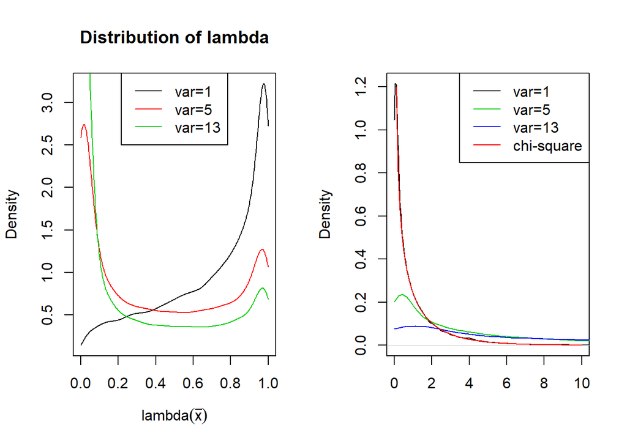

```r
par(mfrow=c(1,2))
#distribution of lambda  #你們的lambda不會跟著變嗎?
#theta0<-1
B<-30000
n<-30
theta0<-1
lambda4<-c();lambda5<-c();lambda6<-c()
for (i in 1:B){
 x4<-rnorm(n, mean = theta0, sd=1)
 xbar4<-mean(x4)
 lambda4[i]<-exp(-n*(xbar4-theta0)^2/2)
 x5<-rnorm(n, mean = theta0, sd=sqrt(5))
 xbar5<-mean(x5)
 lambda5[i]<-exp(-n*(xbar5-theta0)^2/2)
 x6<-rnorm(n, mean = theta0, sd=sqrt(13))
 xbar6<-mean(x6)
 lambda6[i]<-exp(-n*(xbar6-theta0)^2/2)
}
plot(density(lambda4, from = 0,to=1), main="Distribution of lambda",xlab=expression(paste('lambda',(bar(x)))), xlim=c(0,1) )
lines(density(lambda5, from = 0,to=1),col=2)
lines(density(lambda6, from = 0,to=1),col=3)
legend("top", c("var=1","var=5","var=13"), col=c(1,2,3), lty=1)


#theta0=1
B<-30000
n<-30
theta0<-1
lambda4<-c();lambda5<-c();lambda6<-c()
for (i in 1:B){
 x4<-rnorm(n, mean = theta0, sd=1)
 xbar4<-mean(x4)
 lambda4[i]<-exp(-n*(xbar4-theta0)^2/2)
 x5<-rnorm(n, mean = theta0, sd=sqrt(5))
 xbar5<-mean(x5)
 lambda5[i]<-exp(-n*(xbar5-theta0)^2/2)
 x6<-rnorm(n, mean = theta0, sd=sqrt(13))
 xbar6<-mean(x6)
 lambda6[i]<-exp(-n*(xbar6-theta0)^2/2)
}
#under H0(theta=theta_hat) , -2log(lambda)的機率分佈會趨近自由度為1的卡方分配
l1<- -2*log(lambda4)
l2<- -2*log(lambda5)
l3<- -2*log(lambda6)
plot(density(l1, from = 0), main="", xlim=c(0,10), xlab="")
lines(density(l2, from = 0),col=3)
lines(density(l3, from = 0),col=4)
curve(dchisq(x, df=1), from = 0, to=10, add = T, col=2)
legend("topright", c("var=1","var=5","var=13","chi-square"), col=c(1,3,4,2), lty=1)
```

利用-2log(lambda)小於臨界值的機率(chi(1),顯著水準=0.05)  
算出betaP為犯型II錯誤的機率，1-betaP即為檢定力  
畫出當真實參數theta為不同值時，所對應的檢定力圖形  
下圖為比較當變異數/樣本數不同時，power curve所對應的趨勢變化

```r
par(mfrow=c(1,2))
#n=10
mean_beta<-c()
b<-100
s<-seq(1,3,length.out = b)
beta<-c()
betaP<-c()
theta0<-2
#模擬出b個likelihood function
for (o in 1:b) {
  for (j in 1:b) {
    n<-10
    mean<-s[o]
    x<-rnorm(n,mean=mean,sd=1)
    L<-function(mean, x) prod( dnorm(x, mean=mean,sd=1) ) #likelihood function
    theta.hat<-seq(0, 5, length.out = b)
    l<-c()
      for (i in 1:b){
        l[i]<-L(theta.hat[i], x)
      }
    #算出-2log(lambda)小於臨界值的機率(chi(1),顯著水準=0.05)
    mean_beta[j]<-L(theta0,x)/L(theta.hat[which.max(l)],x)
    if (-2*log(mean_beta[j])<qchisq(0.95, 1)){
      beta[j]<-1
    }
    else {
      beta[j]<-0
    }
    betaP[o]<-mean(beta)
  }
  j<-0
}

#算出betaP為犯型II錯誤的機率，1-betaP即為檢定力
power<-1-betaP #p(reject H0 | Ha is true)
#畫出當真實參數theta為不同值時，所對應的檢定力
Smooth.spline=smooth.spline(s,power)
likehood_power_mu_n1<-Smooth.spline
plot(Smooth.spline,main = "power curve", ylab = "probability", xlab = "theta",type = "l",col=2)
theta0hat<-which.min(power)
s[theta0hat] #simulated theta
```

```
## [1] 1.989899
```

```r
theta0 #actual theta
```

```
## [1] 2
```

```r
#verify
#算出alpha為犯型I錯誤的機率
alpha<-c()
for (k in 1:B) {
  if (-2*log(lambda1[k])>=qchisq(0.95, 1)){
    alpha[k]<-1
  }
  else {
    alpha[k]<-0
  }
} # RR={-2*log(lambda)>=(chi-square(1)_alpha=0.05)=3.8415}
mean(alpha) #0.05 , p(reject H0 | H0 is True)
```

```
## [1] 0.04853333
```

```r
#n=50
mean_beta<-c()
b<-100
s<-seq(1,3,length.out = b)
beta<-c()
betaP<-c()
theta0<-2
#模擬出b個likelihood function
for (o in 1:b) {
  for (j in 1:b) {
    n<-50
    mean<-s[o]
    x<-rnorm(n,mean=mean,sd=1)
    L<-function(mean, x) prod( dnorm(x, mean=mean,sd=1) ) #likelihood function
    theta.hat<-seq(0, 5, length.out = b)
    l<-c()
      for (i in 1:b){
        l[i]<-L(theta.hat[i], x)
      }
    #算出-2log(lambda)小於臨界值的機率(chi(1),顯著水準=0.05)
    mean_beta[j]<-L(theta0,x)/L(theta.hat[which.max(l)],x)
    if (-2*log(mean_beta[j])<qchisq(0.95, 1)){
      beta[j]<-1
    }
    else {
      beta[j]<-0
    }
    betaP[o]<-mean(beta)
  }
  j<-0
}
#算出betaP為犯型II錯誤的機率，1-betaP即為檢定力
power<-1-betaP #p(reject H0 | Ha is true)
#畫出當真實參數theta為不同值時，所對應的檢定力
Smooth.spline=smooth.spline(s,power)
likehood_power_mu_n2<-Smooth.spline
lines(Smooth.spline,main = "power curve", ylab = "probability", xlab = "theta",type = "l",col=3)
theta0hat<-which.min(power)
s[theta0hat] #simulated theta
```

```
## [1] 1.929293
```

```r
theta0 #actual theta
```

```
## [1] 2
```

```r
#verify
#算出alpha為犯型I錯誤的機率
alpha<-c()
for (k in 1:B) {
  if (-2*log(lambda2[k])>=qchisq(0.95, 1)){
    alpha[k]<-1
  }
  else {
    alpha[k]<-0
  }
} # RR={-2*log(lambda)>=(chi-square(1)_alpha=0.05)=3.8415}
mean(alpha) #0.05 , p(reject H0 | H0 is True)
```

```
## [1] 0.0507
```

```r
#n=200
mean_beta<-c()
b<-100
s<-seq(1,3,length.out = b)
beta<-c()
betaP<-c()
theta0<-2
#模擬出b個likelihood function
for (o in 1:b) {
  for (j in 1:b) {
    n<-200
    mean<-s[o]
    x<-rnorm(n,mean=mean,sd=1)
    L<-function(mean, x) prod( dnorm(x, mean=mean,sd=1) ) #likelihood function
    theta.hat<-seq(0, 5, length.out = b)
    l<-c()
      for (i in 1:b){
        l[i]<-L(theta.hat[i], x)
      }
    #算出-2log(lambda)小於臨界值的機率(chi(1),顯著水準=0.05)
    mean_beta[j]<-L(theta0,x)/L(theta.hat[which.max(l)],x)
    if (-2*log(mean_beta[j])<qchisq(0.95, 1)){
      beta[j]<-1
    }
    else {
      beta[j]<-0
    }
    betaP[o]<-mean(beta)
  }
  j<-0
}
#算出betaP為犯型II錯誤的機率，1-betaP即為檢定力
power<-1-betaP #p(reject H0 | Ha is true)
#畫出當真實參數theta為不同值時，所對應的檢定力
Smooth.spline=smooth.spline(s,power)
likehood_power_mu_n3<-Smooth.spline
lines(Smooth.spline,main = "power curve", ylab = "probability", xlab = "theta",type = "l",col=4)
theta0hat<-which.min(power)
s[theta0hat] #simulated theta
```

```
## [1] 1.989899
```

```r
theta0 #actual theta
```

```
## [1] 2
```

```r
#verify
#算出alpha為犯型I錯誤的機率
alpha<-c()
for (k in 1:B) {
  if (-2*log(lambda3[k])>=qchisq(0.95, 1)){
    alpha[k]<-1
  }
  else {
    alpha[k]<-0
  }
} # RR={-2*log(lambda)>=(chi-square(1)_alpha=0.05)=3.8415}
mean(alpha) #0.05 , p(reject H0 | H0 is True)
```

```
## [1] 0.04896667
```

```r
legend("topright",c("n=10","n=50","n=200"),col = c(2,3,4),lty = 1)

#var=1
mean_beta<-c()
b<-100
s<-seq(1,3,length.out = b)
beta<-c()
betaP<-c()
theta0<-2
#模擬出b個likelihood function
for (o in 1:b) {
  for (j in 1:b) {
    n<-50
    mean<-s[o]
    x<-rnorm(n,mean=mean,sd=1)
    L<-function(mean, x) prod( dnorm(x, mean=mean,sd=1) ) #likelihood function
    theta.hat<-seq(0, 5, length.out = b)
    l<-c()
      for (i in 1:b){
        l[i]<-L(theta.hat[i], x)
      }
    #算出-2log(lambda)小於臨界值的機率(chi(1),顯著水準=0.05)
    mean_beta[j]<-L(theta0,x)/L(theta.hat[which.max(l)],x)
    if (-2*log(mean_beta[j])<qchisq(0.95, 1)){
      beta[j]<-1
    }
    else {
      beta[j]<-0
    }
    betaP[o]<-mean(beta)
  }
  j<-0
}
#算出betaP為犯型II錯誤的機率，1-betaP即為檢定力
power<-1-betaP#p(reject H0 | Ha is true)
#畫出當真實參數theta為不同值時，所對應的檢定力
Smooth.spline=smooth.spline(s,power)
likehood_power_mu_var1<-Smooth.spline
plot(Smooth.spline,main = "power curve", ylab = "probability", xlab = "theta",type = "l",col=2)
theta0hat<-which.min(power)
s[theta0hat] #simulated theta
```

```
## [1] 2.030303
```

```r
theta0 #actual theta
```

```
## [1] 2
```

```r
#verify
#算出alpha為犯型I錯誤的機率
alpha<-c()
for (k in 1:B) {
  if (-2*log(lambda4[k])>=qchisq(0.95, 1)){
    alpha[k]<-1
  }
  else {
    alpha[k]<-0
  }
} # RR={-2*log(lambda)>=(chi-square(1)_alpha=0.05)=3.8415}
mean(alpha) #0.05 , p(reject H0 | H0 is True)
```

```
## [1] 0.05156667
```

```r
#var=5
mean_beta<-c()
b<-100
s<-seq(1,3,length.out = b)
beta<-c()
betaP<-c()
theta0<-2
#模擬出b個likelihood function
for (o in 1:b) {
  for (j in 1:b) {
    n<-50
    mean<-s[o]
    x<-rnorm(n,mean=mean,sd=sqrt(5))
    L<-function(mean, x) prod( dnorm(x, mean=mean,sd=sqrt(5)) ) #likelihood function
    theta.hat<-seq(0, 5, length.out = b)
    l<-c()
      for (i in 1:b){
        l[i]<-L(theta.hat[i], x)
      }
    #算出-2log(lambda)小於臨界值的機率(chi(1),顯著水準=0.05)
    mean_beta[j]<-L(theta0,x)/L(theta.hat[which.max(l)],x)
    if (-2*log(mean_beta[j])<qchisq(0.95, 1)){
      beta[j]<-1
    }
    else {
      beta[j]<-0
    }
    betaP[o]<-mean(beta)
  }
  j<-0
}
#算出betaP為犯型II錯誤的機率，1-betaP即為檢定力
power<-1-betaP #p(reject H0 | Ha is true)
#畫出當真實參數theta為不同值時，所對應的檢定力
Smooth.spline=smooth.spline(s,power)
likehood_power_mu_var2<-Smooth.spline
lines(Smooth.spline,main = "power curve", ylab = "probability", xlab = "theta",type = "l",col=3)
theta0hat<-which.min(power)
s[theta0hat] #simulated theta
```

```
## [1] 1.929293
```

```r
theta0 #actual theta
```

```
## [1] 2
```

```r
#verify
#算出alpha為犯型I錯誤的機率
alpha<-c()
for (k in 1:B) {
  if (-2*log(lambda5[k])>=qchisq(0.95, 1)){
    alpha[k]<-1
  }
  else {
    alpha[k]<-0
  }
} # RR={-2*log(lambda)>=(chi-square(1)_alpha=0.05)=3.8415}
mean(alpha) #0.05 , p(reject H0 | H0 is True)
```

```
## [1] 0.3832333
```

```r
#var=13
mean_beta<-c()
b<-100
s<-seq(1,3,length.out = b)
beta<-c()
betaP<-c()
theta0<-2
#模擬出b個likelihood function
for (o in 1:b) {
  for (j in 1:b) {
    n<-50
    mean<-s[o]
    x<-rnorm(n,mean=mean,sd=sqrt(13))
    L<-function(mean, x) prod( dnorm(x, mean=mean,sd=sqrt(13)) ) #likelihood function
    theta.hat<-seq(0, 5, length.out = b)
    l<-c()
      for (i in 1:b){
        l[i]<-L(theta.hat[i], x)
      }
    #算出-2log(lambda)小於臨界值的機率(chi(1),顯著水準=0.05)
    mean_beta[j]<-L(theta0,x)/L(theta.hat[which.max(l)],x)
    if (-2*log(mean_beta[j])<qchisq(0.95, 1)){
      beta[j]<-1
    }
    else {
      beta[j]<-0
    }
    betaP[o]<-mean(beta)
  }
  j<-0
}
#算出betaP為犯型II錯誤的機率，1-betaP即為檢定力
power<-1-betaP #p(reject H0 | Ha is true)
#畫出當真實參數theta為不同值時，所對應的檢定力
Smooth.spline=smooth.spline(s,power)
likehood_power_mu_var3<-Smooth.spline
lines(Smooth.spline,main = "power curve", ylab = "probability", xlab = "theta",type = "l",col=4)
theta0hat<-which.min(power)
s[theta0hat] #simulated theta
```

```
## [1] 1.909091
```

```r
theta0 #actual theta
```

```
## [1] 2
```

```r
#verify
#算出alpha為犯型I錯誤的機率
alpha<-c()
for (k in 1:B) {
  if (-2*log(lambda6[k])>=qchisq(0.95, 1)){
    alpha[k]<-1
  }
  else {
    alpha[k]<-0
  }
} # RR={-2*log(lambda)>=(chi-square(1)_alpha=0.05)=3.8415}
mean(alpha) #0.05 , p(reject H0 | H0 is True)
```

```
## [1] 0.5888333
```

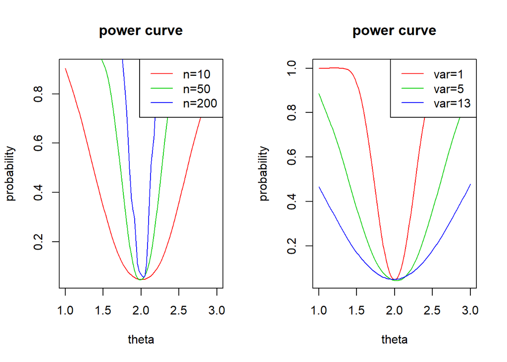

```r
legend("topright",c("var=1","var=5","var=13"),col = c(2,3,4),lty = 1)
```

## Normal Distribution N(0,theta)

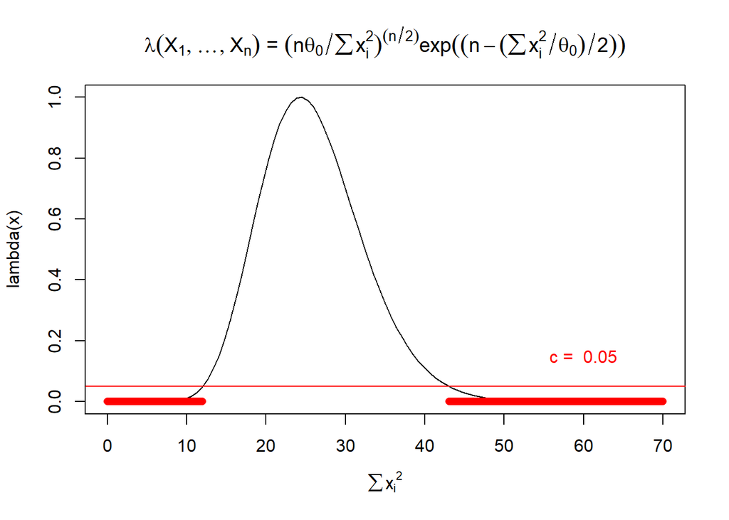

```r
#normal(0,theta)
c<-0.05
lambda<-function(sumx2, theta0=0.81, n=30) (n*theta0/sumx2)^(-n/2)*exp((n-sumx2/theta0)/2) # LRT statistic
curve(lambda, from=0, to=70, xlab=expression(sum(x[i])^2), main=expression(paste(lambda(X[1],...,X[n])," = ", (n*theta[0]/sum(x[i]^2))^(n/2)*exp((n-(sum(x[i]^2)/theta[0])/2)))) )
abline(h=c, col=2)
text(60, c+0.1, paste("c = ", c), col=2)
RR<-seq(0, 70, 0.01)[lambda(seq(0, 70, 0.01) )< c]
points(RR, rep(0, length(RR)), col=2, pch=16 )
```

normal(0,theta)之下lambda的分配圖形，在不同的樣本數之下的趨勢改變

normal(0,theta)，將lambda取-2log後，會服從卡方分配

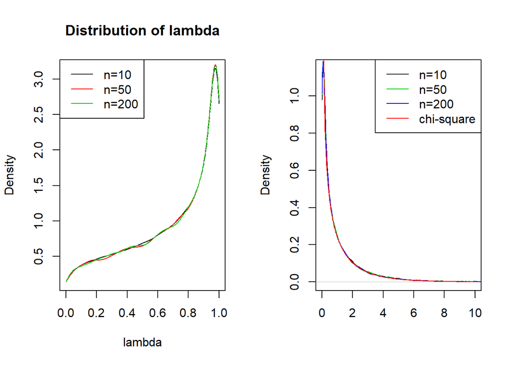

```r
par(mfrow=c(1,2))
#distribution of lambda
#theta0<-0.81
B<-30000
n1<-10;n2<-50;n3<-200
theta0<-0.81
lambda1<-c();lambda2<-c();lambda3<-c();
for (i in 1:B){
 x1<-rnorm(n1, mean = 0, sd= sqrt(theta0))
 sumx21<-sum(x1^2)
 lambda1[i]<-(n1*theta0/sumx21)^(-n1/2)*exp((n1-sumx21/theta0)/2)
 x2<-rnorm(n2, mean = 0, sd= sqrt(theta0))
 sumx22<-sum(x2^2)
 lambda2[i]<-(n2*theta0/sumx22)^(-n2/2)*exp((n2-sumx22/theta0)/2)
 x3<-rnorm(n3, mean = 0, sd= sqrt(theta0))
 sumx23<-sum(x3^2)
 lambda3[i]<-(n3*theta0/sumx23)^(-n3/2)*exp((n3-sumx23/theta0)/2)
}
plot(density(lambda1, from = 0,to=1), main="Distribution of lambda",xlab='lambda', xlim=c(0,1) )
lines(density(lambda2, from = 0,to=1),col=2)
lines(density(lambda3, from = 0,to=1),col=3)
legend("topleft", c("n=10","n=50","n=200"), col=c(1,2,3), lty=1)


#theta0=0.81
B<-30000
n<-50
theta0<-0.81
lambda1<-c();lambda2<-c();lambda3<-c();
for (i in 1:B){
 x1<-rnorm(n1, mean = 0, sd= sqrt(theta0))
 sumx21<-sum(x1^2)
 lambda1[i]<-(n1*theta0/sumx21)^(-n1/2)*exp((n1-sumx21/theta0)/2)
 x2<-rnorm(n2, mean = 0, sd= sqrt(theta0))
 sumx22<-sum(x2^2)
 lambda2[i]<-(n2*theta0/sumx22)^(-n2/2)*exp((n2-sumx22/theta0)/2)
 x3<-rnorm(n3, mean = 0, sd= sqrt(theta0))
 sumx23<-sum(x3^2)
 lambda3[i]<-(n3*theta0/sumx23)^(-n3/2)*exp((n3-sumx23/theta0)/2)
}
#under H0(theta=theta_hat) , -2log(lambda)的機率分佈會趨近自由度為1的卡方分配
l<- -2*log(lambda1)
l1<- -2*log(lambda2)
l2<- -2*log(lambda3)
plot(density(l, from = 0), main="", xlim=c(0,10), xlab="")
lines(density(l1, from = 0),col=3)
lines(density(l2, from = 0),col=4)
curve(dchisq(x, df=1), from = 0, to=10, add = T, col=2)
legend("topright", c("n=10","n=50","n=200","chi-square"), col=c(1,3,4,2), lty=1)
```

normal(0,theta)之下lambda的分配圖形，在不同的平均數之下的趨勢改變

normal(0,theta)，在不同的平均數下，將各lambda取-2log後，皆會服從卡方分配

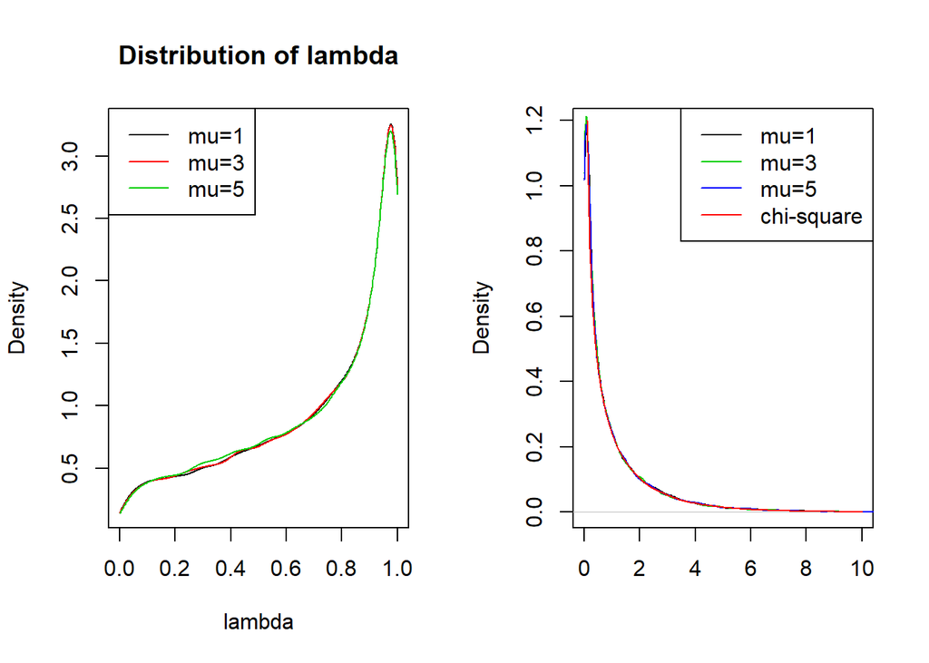

```r
par(mfrow=c(1,2))
#distribution of lambda
#theta0<-0.81
B<-30000
n<-50
theta0<-0.81
lambda4<-c();lambda5<-c();lambda6<-c();
for (i in 1:B){
  mean=c(1,3,5)
 x4<-rnorm(n, mean = mean[1], sd= sqrt(theta0))
 sumx24<-sum((x4-mean[1])^2)
 lambda4[i]<-(n*theta0/sumx24)^(-n/2)*exp((n-sumx24/theta0)/2)
 x5<-rnorm(n, mean = mean[2], sd= sqrt(theta0))
 sumx25<-sum((x5-mean[2])^2)
 lambda5[i]<-(n*theta0/sumx25)^(-n/2)*exp((n-sumx25/theta0)/2)
 x6<-rnorm(n, mean = mean[3], sd= sqrt(theta0))
 sumx26<-sum((x6-mean[3])^2)
 lambda6[i]<-(n*theta0/sumx26)^(-n/2)*exp((n-sumx26/theta0)/2)
}
plot(density(lambda4, from = 0,to=1), main="Distribution of lambda",xlab='lambda', xlim=c(0,1) )
lines(density(lambda5, from = 0,to=1),col=2)
lines(density(lambda6, from = 0,to=1),col=3)
legend("topleft", c("mu=1","mu=3","mu=5"), col=c(1,2,3), lty=1)

#theta0=0.81
B<-30000
n<-50
theta0<-0.81
lambda4<-c();lambda5<-c();lambda6<-c();
for (i in 1:B){
  mean=c(1,3,5)
 x4<-rnorm(n, mean = mean[1], sd= sqrt(theta0))
 sumx4<-sum((x4-mean[1])^2)
 lambda4[i]<-(n*theta0/sumx4)^(-n/2)*exp((n-sumx4/theta0)/2)
 x5<-rnorm(n, mean = mean[2], sd= sqrt(theta0))
 sumx25<-sum((x5-mean[2])^2)
 lambda5[i]<-(n*theta0/sumx25)^(-n/2)*exp((n-sumx25/theta0)/2)
 x6<-rnorm(n, mean = mean[3], sd= sqrt(theta0))
 sumx26<-sum((x6-mean[3])^2)
 lambda6[i]<-(n*theta0/sumx26)^(-n/2)*exp((n-sumx26/theta0)/2)
}
#under H0(theta=theta_hat) , -2log(lambda)的機率分佈會趨近自由度為1的卡方分配
l<- -2*log(lambda4)
l1<- -2*log(lambda5)
l2<- -2*log(lambda6)
plot(density(l, from = 0), main="", xlim=c(0,10), xlab="")
lines(density(l1, from = 0),col=3)
lines(density(l2, from = 0),col=4)
curve(dchisq(x, df=1), from = 0, to=10, add = T, col=2)
legend("topright", c("mu=1","mu=3","mu=5","chi-square"), col=c(1,3,4,2), lty=1)
```

利用-2log(lambda)小於臨界值的機率(chi(1),顯著水準=0.05) 算出betaP為犯型II錯誤的機率，1-betaP即為檢定力  
畫出當真實參數theta為不同值時，所對應的檢定力圖形  
下圖為比較當平均數不同時，power curve所對應的趨勢變化

```r
par(mfrow=c(1,2))
#n=10
s2_beta<-c()
b<-100
s<-seq(0.2, 2, length.out =100)
beta<-c()
betaP<-c()
theta0<-0.81
#模擬出b個likelihood function
for (o in 1:b) {
  for (j in 1:b) {
    n<-10
    s2<-s[o]
    x<-rnorm(n,mean=0,sd=sqrt(s2))
    L<-function(s2, x) prod( dnorm(x, mean=0,sd=sqrt(s2)) ) #likelihood function
    theta.hat<-seq(0, 3, length.out = b)
    l<-c()
      for (i in 1:b){
        l[i]<-L(theta.hat[i], x)
      }
    #算出-2log(lambda)小於臨界值的機率(chi(1),顯著水準=0.01)
    s2_beta[j]<-L(theta0,x)/L(theta.hat[which.max(l)],x)
    if (-2*log(s2_beta[j])<qchisq(0.95, 1)){
      beta[j]<-1
    }
    else {
      beta[j]<-0
    }
    betaP[o]<-mean(beta)
  }
  j<-0
}
#算出betaP為犯型II錯誤的機率，1-betaP即為檢定力
power<-1-betaP #p(reject H0 | Ha is true)
#畫出當真實參數theta為不同值時，所對應的檢定力
Smooth.spline=smooth.spline(s,power)
likehood_power_var_n1<-Smooth.spline
plot(Smooth.spline,main = "power curve", ylab = "probability", xlab = "theta",type = "l",col=2)
theta0hat<-which.min(power)
s[theta0hat] #simulated theta
```

```
## [1] 0.7090909
```

```r
theta0 #actual theta
```

```
## [1] 0.81
```

```r
#算出alpha為犯型I錯誤的機率
#verify
alpha<-c()
for (k in 1:B) {
  if (-2*log(lambda1[k])>=qchisq(0.95, 1)){
    alpha[k]<-1
  }
  else {
    alpha[k]<-0
  }
} # RR={-2*log(lambda)>=(chi-square(1)_alpha=0.05)=3.8415}
mean(alpha) #0.05 , p(reject H0 | H0 is True)
```

```
## [1] 0.0548
```

```r
#n=50
s2_beta<-c()
b<-100
s<-seq(0.2, 2, length.out =100)
beta<-c()
betaP<-c()
theta0<-0.81
#模擬出b個likelihood function
for (o in 1:b) {
  for (j in 1:b) {
    n<-50
    s2<-s[o]
    x<-rnorm(n,mean=0,sd=sqrt(s2))
    L<-function(s2, x) prod( dnorm(x, mean=0,sd=sqrt(s2)) ) #likelihood function
    theta.hat<-seq(0, 3, length.out = b)
    l<-c()
      for (i in 1:b){
        l[i]<-L(theta.hat[i], x)
      }
    #算出-2log(lambda)小於臨界值的機率(chi(1),顯著水準=0.01)
    s2_beta[j]<-L(theta0,x)/L(theta.hat[which.max(l)],x)
    if (-2*log(s2_beta[j])<qchisq(0.95, 1)){
      beta[j]<-1
    }
    else {
      beta[j]<-0
    }
    betaP[o]<-mean(beta)
  }
  j<-0
}
#算出betaP為犯型II錯誤的機率，1-betaP即為檢定力
power<-1-betaP #p(reject H0 | Ha is true)
#畫出當真實參數theta為不同值時，所對應的檢定力
Smooth.spline=smooth.spline(s,power)
likehood_power_var_n2<-Smooth.spline
lines(Smooth.spline,main = "power curve", ylab = "probability", xlab = "theta",type = "l",col=3)
theta0hat<-which.min(power)
s[theta0hat] #simulated theta
```

```
## [1] 0.7454545
```

```r
theta0 #actual theta
```

```
## [1] 0.81
```

```r
#算出alpha為犯型I錯誤的機率
#verify
alpha<-c()
for (k in 1:B) {
  if (-2*log(lambda2[k])>=qchisq(0.95, 1)){
    alpha[k]<-1
  }
  else {
    alpha[k]<-0
  }
} # RR={-2*log(lambda)>=(chi-square(1)_alpha=0.05)=3.8415}
mean(alpha) #0.05 , p(reject H0 | H0 is True)
```

```
## [1] 0.0517
```

```r
#n=200
s2_beta<-c()
b<-100
s<-seq(0.2, 2, length.out =100)
beta<-c()
betaP<-c()
theta0<-0.81
#模擬出b個likelihood function
for (o in 1:b) {
  for (j in 1:b) {
    n<-200
    s2<-s[o]
    x<-rnorm(n,mean=0,sd=sqrt(s2))
    L<-function(s2, x) prod( dnorm(x, mean=0,sd=sqrt(s2)) ) #likelihood function
    theta.hat<-seq(0, 3, length.out = b)
    l<-c()
      for (i in 1:b){
        l[i]<-L(theta.hat[i], x)
      }
    #算出-2log(lambda)小於臨界值的機率(chi(1),顯著水準=0.01)
    s2_beta[j]<-L(theta0,x)/L(theta.hat[which.max(l)],x)
    if (-2*log(s2_beta[j])<qchisq(0.95, 1)){
      beta[j]<-1
    }
    else {
      beta[j]<-0
    }
    betaP[o]<-mean(beta)
  }
  j<-0
}
#算出betaP為犯型II錯誤的機率，1-betaP即為檢定力
power<-1-betaP #p(reject H0 | Ha is true)
#畫出當真實參數theta為不同值時，所對應的檢定力
Smooth.spline=smooth.spline(s,power)
likehood_power_var_n3<-Smooth.spline
lines(Smooth.spline,main = "power curve", ylab = "probability", xlab = "theta",type = "l",col=4)
theta0hat<-which.min(power)
s[theta0hat] #simulated theta
```

```
## [1] 0.8
```

```r
theta0 #actual theta
```

```
## [1] 0.81
```

```r
#算出alpha為犯型I錯誤的機率
#verify
alpha<-c()
for (k in 1:B) {
  if (-2*log(lambda3[k])>=qchisq(0.95, 1)){
    alpha[k]<-1
  }
  else {
    alpha[k]<-0
  }
} # RR={-2*log(lambda)>=(chi-square(1)_alpha=0.05)=3.8415}
mean(alpha) #0.05 , p(reject H0 | H0 is True)
```

```
## [1] 0.05103333
```

```r
legend("topright",c("n=10","n=50","n=200"),col = c(2,3,4),lty = 1)

#mean=1
s2_beta<-c()
b<-100
s<-seq(0.2, 2, length.out =100)
beta<-c()
betaP<-c()
theta0<-0.81
#模擬出b個likelihood function
for (o in 1:b) {
  for (j in 1:b) {
    n<-50
    s2<-s[o]
    x<-rnorm(n,mean=1,sd=sqrt(s2))
    L<-function(s2, x) prod( dnorm(x, mean=1,sd=sqrt(s2)) ) #likelihood function
    theta.hat<-seq(0, 3, length.out = b)
    l<-c()
      for (i in 1:b){
        l[i]<-L(theta.hat[i], x)
      }
    #算出-2log(lambda)小於臨界值的機率(chi(1),顯著水準=0.01)
    s2_beta[j]<-L(theta0,x)/L(theta.hat[which.max(l)],x)
    if (-2*log(s2_beta[j])<qchisq(0.95, 1)){
      beta[j]<-1
    }
    else {
      beta[j]<-0
    }
    betaP[o]<-mean(beta)
  }
  j<-0
}
#算出betaP為犯型II錯誤的機率，1-betaP即為檢定力
power<-1-betaP #p(reject H0 | Ha is true)
#畫出當真實參數theta為不同值時，所對應的檢定力
Smooth.spline=smooth.spline(s,power)
likehood_power_var_mean1<-Smooth.spline
plot(Smooth.spline,main = "power curve", ylab = "probability", xlab = "theta",type = "l",col=2)
theta0hat<-which.min(power)
s[theta0hat] #simulated theta
```

```
## [1] 0.8
```

```r
theta0 #actual theta
```

```
## [1] 0.81
```

```r
#算出alpha為犯型I錯誤的機率
#verify
alpha<-c()
for (k in 1:B) {
  if (-2*log(lambda4[k])>=qchisq(0.95, 1)){
    alpha[k]<-1
  }
  else {
    alpha[k]<-0
  }
} # RR={-2*log(lambda)>=(chi-square(1)_alpha=0.05)=3.8415}
mean(alpha) #0.05 , p(reject H0 | H0 is True)
```

```
## [1] 0.05146667
```

```r
#mean=3
s2_beta<-c()
b<-100
s<-seq(0.2, 2, length.out =100)
beta<-c()
betaP<-c()
theta0<-0.81
#模擬出b個likelihood function
for (o in 1:b) {
  for (j in 1:b) {
    n<-50
    s2<-s[o]
    x<-rnorm(n,mean=3,sd=sqrt(s2))
    L<-function(s2, x) prod( dnorm(x, mean=3,sd=sqrt(s2)) ) #likelihood function
    theta.hat<-seq(0, 3, length.out = b)
    l<-c()
      for (i in 1:b){
        l[i]<-L(theta.hat[i], x)
      }
    #算出-2log(lambda)小於臨界值的機率(chi(1),顯著水準=0.01)
    s2_beta[j]<-L(theta0,x)/L(theta.hat[which.max(l)],x)
    if (-2*log(s2_beta[j])<qchisq(0.95, 1)){
      beta[j]<-1
    }
    else {
      beta[j]<-0
    }
    betaP[o]<-mean(beta)
  }
  j<-0
}
#算出betaP為犯型II錯誤的機率，1-betaP即為檢定力
power<-1-betaP #p(reject H0 | Ha is true)
#畫出當真實參數theta為不同值時，所對應的檢定力
Smooth.spline=smooth.spline(s,power)
likehood_power_var_mean2<-Smooth.spline
lines(Smooth.spline,main = "power curve", ylab = "probability", xlab = "theta",type = "l",col=3)
theta0hat<-which.min(power)
s[theta0hat] #simulated theta
```

```
## [1] 0.8545455
```

```r
theta0 #actual theta
```

```
## [1] 0.81
```

```r
#算出alpha為犯型I錯誤的機率
#verify
alpha<-c()
for (k in 1:B) {
  if (-2*log(lambda5[k])>=qchisq(0.95, 1)){
    alpha[k]<-1
  }
  else {
    alpha[k]<-0
  }
} # RR={-2*log(lambda)>=(chi-square(1)_alpha=0.05)=3.8415}
mean(alpha) #0.05 , p(reject H0 | H0 is True)
```

```
## [1] 0.04926667
```

```r
#mean=5
s2_beta<-c()
b<-100
s<-seq(0.2, 2, length.out =100)
beta<-c()
betaP<-c()
theta0<-0.81
#模擬出b個likelihood function
for (o in 1:b) {
  for (j in 1:b) {
    n<-50
    s2<-s[o]
    x<-rnorm(n,mean=5,sd=sqrt(s2))
    L<-function(s2, x) prod( dnorm(x, mean=5,sd=sqrt(s2)) ) #likelihood function
    theta.hat<-seq(0, 3, length.out = b)
    l<-c()
      for (i in 1:b){
        l[i]<-L(theta.hat[i], x)
      }
    #算出-2log(lambda)小於臨界值的機率(chi(1),顯著水準=0.01)
    s2_beta[j]<-L(theta0,x)/L(theta.hat[which.max(l)],x)
    if (-2*log(s2_beta[j])<qchisq(0.95, 1)){
      beta[j]<-1
    }
    else {
      beta[j]<-0
    }
    betaP[o]<-mean(beta)
  }
  j<-0
}
#算出betaP為犯型II錯誤的機率，1-betaP即為檢定力
power<-1-betaP #p(reject H0 | Ha is true)
#畫出當真實參數theta為不同值時，所對應的檢定力
Smooth.spline=smooth.spline(s,power)
likehood_power_var_mean3<-Smooth.spline
lines(Smooth.spline,main = "power curve", ylab = "probability", xlab = "theta",type = "l",col=4)
theta0hat<-which.min(power)
s[theta0hat] #simulated theta
```

```
## [1] 0.7818182
```

```r
theta0 #actual theta
```

```
## [1] 0.81
```

```r
#算出alpha為犯型I錯誤的機率
#verify
alpha<-c()
for (k in 1:B) {
  if (-2*log(lambda6[k])>=qchisq(0.95, 1)){
    alpha[k]<-1
  }
  else {
    alpha[k]<-0
  }
} # RR={-2*log(lambda)>=(chi-square(1)_alpha=0.05)=3.8415}
mean(alpha) #0.05 , p(reject H0 | H0 is True)
```

```
## [1] 0.05283333
```

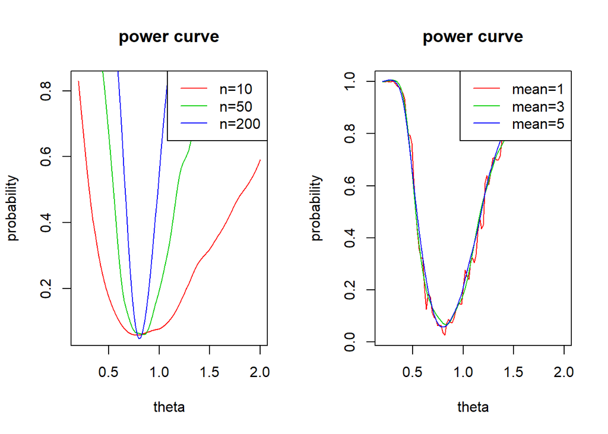

```r
legend("topright",c("mean=1","mean=3","mean=5"),col = c(2,3,4),lty = 1)
```

## Exponential distribution exp(rate)

當lambda=2 & 等於0.5及1時的exponential distribution 圖形。

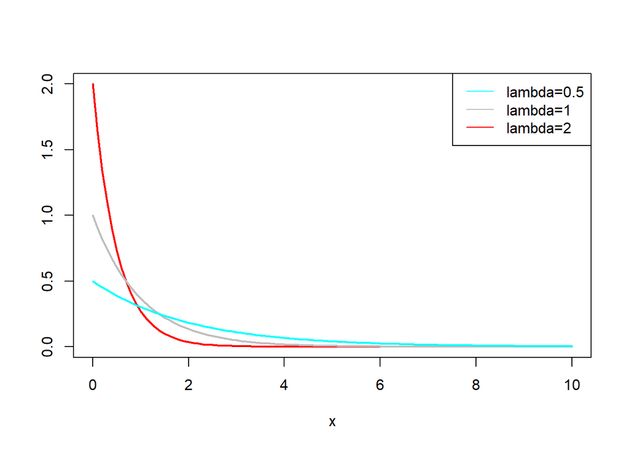

```r
x <- seq(0, 10, 0.1)

# lambda = 2
plot(x, dexp(x, 2), type = "l",ylab = "", lwd = 2, col = 2)
# lambda = 1
lines(x, dexp(x, rate = 1), col = 8, lty = 1, lwd = 2)
# lambda = 0.5
lines(x, dexp(x, rate = 0.5), col = 5, lty = 1, lwd = 2)

legend("topright", c("lambda=0.5","lambda=1","lambda=2"), col=c(5,8,2), lty=1)
```

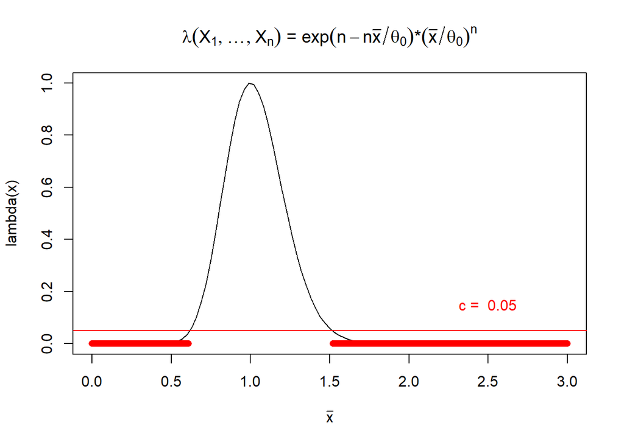

```r
#exponential
c<-0.05
lambda<-function(xbar, theta0=1, n=30) exp(n-n*xbar/theta0)*xbar^n/theta0^n # LRT statistic
curve(lambda, from=0, to=3, xlab=expression(bar(x)), main=expression(paste(lambda(X[1],...,X[n])," = ", exp(n-n*bar(x)/theta[0]),"*",(bar(x)/theta[0])^n)) )
abline(h=c, col=2)
text(2.5, c+0.1, paste("c = ", c), col=2)
RR<-seq(0, 3, 0.01)[lambda(seq(0, 3, 0.01) )< c]
points(RR, rep(0, length(RR)), col=2, pch=16 )
```

exp(theta)之下lambda的分配圖形，在不同的樣本數之下的趨勢改變

exp(theta)，將lambda取-2log後，會服從卡方分配

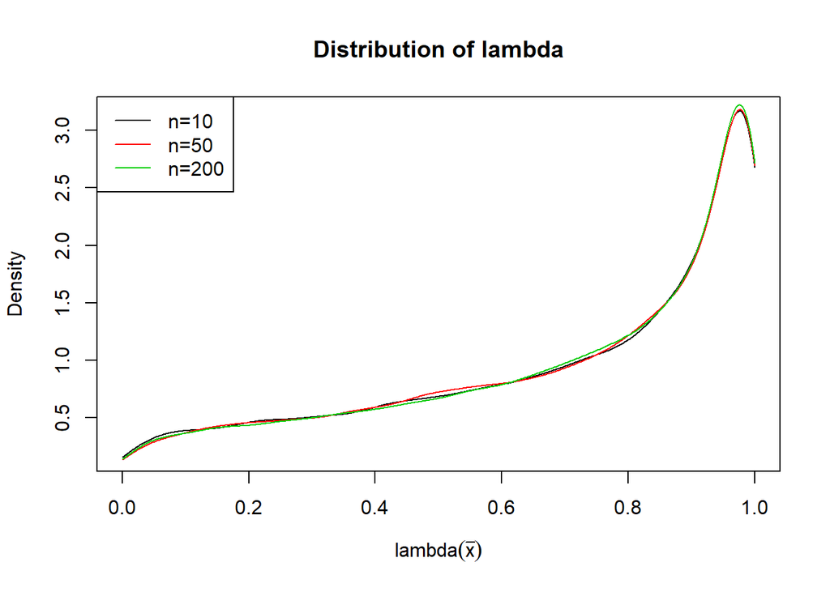

```r
#distribution of lambda
#theta0=1
B<-30000
n1<-10;n2<-50;n3<-200
theta0<-1
lambda1<-c();lambda2<-c();lambda3<-c()
for (i in 1:B){
 x1<-rexp(n1, rate = theta0)
 xbar1<-mean(x1)
 lambda1[i]<-exp(n1-n1*xbar1/theta0)*(xbar1/theta0)^n1
 x2<-rexp(n2, rate = theta0)
 xbar2<-mean(x2)
 lambda2[i]<-exp(n2-n2*xbar2/theta0)*(xbar2/theta0)^n2
 x3<-rexp(n3, rate = theta0)
 xbar3<-mean(x3)
 lambda3[i]<-exp(n3-n3*xbar3/theta0)*(xbar3/theta0)^n3
}
plot(density(lambda1, from = 0,to=1), main="Distribution of lambda",xlab=expression(paste('lambda',(bar(x)))), xlim=c(0,1) )
lines(density(lambda2, from = 0,to=1),col=2)
lines(density(lambda3, from = 0,to=1),col=3)
legend("topleft", c("n=10","n=50","n=200"), col=c(1,2,3), lty=1)
```

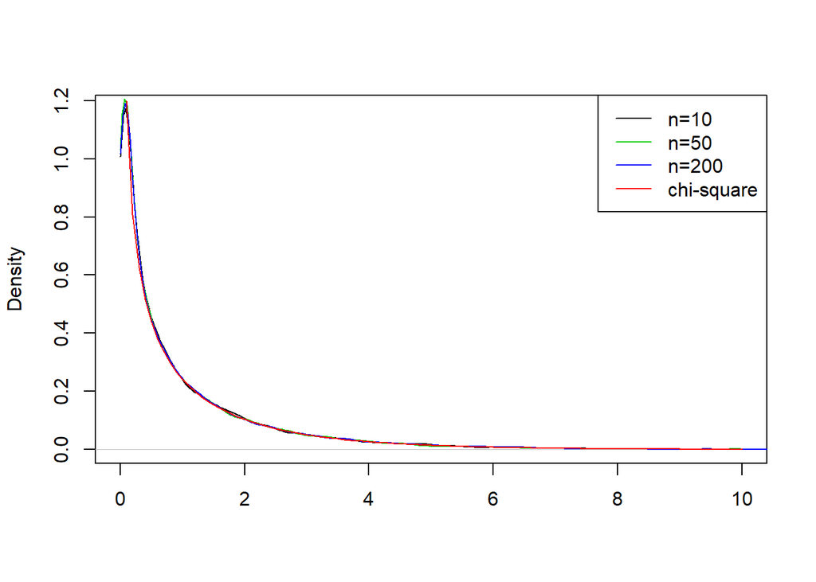

```r
#distribution of lambda
#theta0=1
B<-30000
n1<-10;n2<-50;n3<-200
theta0<-1
lambda1<-c();lambda2<-c();lambda3<-c()
for (i in 1:B){
 x1<-rexp(n1, rate = theta0)
 xbar1<-mean(x1)
 lambda1[i]<-exp(n1-n1*xbar1/theta0)*(xbar1/theta0)^n1
 x2<-rexp(n2, rate = theta0)
 xbar2<-mean(x2)
 lambda2[i]<-exp(n2-n2*xbar2/theta0)*(xbar2/theta0)^n2
 x3<-rexp(n3, rate = theta0)
 xbar3<-mean(x3)
 lambda3[i]<-exp(n3-n3*xbar3/theta0)*(xbar3/theta0)^n3
}
#under H0(theta=theta_hat) , -2log(lambda)的機率分佈會趨近自由度為1的卡方分配
l1<- -2*log(lambda1)
l2<- -2*log(lambda2)
l3<- -2*log(lambda3)
plot(density(l1, from = 0), main="", xlim=c(0,10), xlab="")
lines(density(l2, from = 0),col=3)
lines(density(l3, from = 0),col=4)
curve(dchisq(x, df=1), from = 0, to=10, add = T, col=2)
legend("topright", c("n=10","n=50","n=200","chi-square"), col=c(1,3,4,2), lty=1)
```

利用-2log(lambda)小於臨界值的機率(chi(1),顯著水準=0.05)  
算出betaP為犯型II錯誤的機率，1-betaP即為檢定力  
畫出當真實參數theta為不同值時，所對應的檢定力圖形  
下圖為比較當樣本數不同時，power curve所對應的趨勢變化

```r
#n=10
lambda_beta<-c()
b<-100
s<-seq(1,3,length.out = b)
beta<-c()
betaP<-c()
#模擬出b個likelihood function
for (o in 1:b) {
  for (j in 1:b) {
    n<-10
    rate<-2
    x<-rexp(n,rate=s[o])
    L<-function(rate, x) prod( dexp(x, rate) ) #likelihood function
    theta.hat<-seq(0, 5, length.out = b)
    l<-c()
      for (i in 1:b){
        l[i]<-L(theta.hat[i], x)
      }
    #算出-2log(lambda)小於臨界值的機率(chi(1),顯著水準=0.05)
    lambda_beta[j]<-L(rate,x)/L(theta.hat[which.max(l)],x)
    if (-2*log(lambda_beta[j])<qchisq(0.95, 1)){
      beta[j]<-1
    }
    else {
      beta[j]<-0
    }
    betaP[o]<-mean(beta)
  }
  beta<-c()
  j<-0
}
#算出betaP為犯型II錯誤的機率，1-betaP即為檢定力
power<-1-betaP #p(reject H0 | Ha is true)
#畫出當真實參數theta為不同值時，所對應的檢定力
S=smooth.spline(s,power)
likehood_power_rate_n1<-S
plot(S,main = "power curve", ylab = "probability", xlab = "theta",type="l",col=2,lty=1)
theta0_10<-which.min(power)
s[theta0_10] #simulated theta
```

```
## [1] 1.767677
```

```r
rate #actual theta
```

```
## [1] 2
```

```r
#verify
#算出alpha為犯型I錯誤的機率
alpha_10<-c()
for (k in 1:B) {
  if (-2*log(lambda1[k])>=qchisq(0.95, 1)){
    alpha_10[k]<-1
  }
  else {
    alpha_10[k]<-0
  }
} # RR={-2*log(lambda)>=(chi-square(1)_alpha=0.01)=qchisq(0.95, 1)}
mean(alpha_10) #0.05 , p(reject H0 | H0 is True)
```

```
## [1] 0.9952667
```

```r
likehood_power_rate<-power

#n=50
lambda_beta<-c()
b<-100
s<-seq(1,3,length.out = b)
beta<-c()
betaP<-c()
#模擬出b個likelihood function
for (o in 1:b) {
  for (j in 1:b) {
    n<-50
    rate<-2
    x<-rexp(n,rate=s[o])
    L<-function(rate, x) prod( dexp(x, rate) ) #likelihood function
    theta.hat<-seq(0, 5, length.out = b)
    l<-c()
      for (i in 1:b){
        l[i]<-L(theta.hat[i], x)
      }
    #算出-2log(lambda)小於臨界值的機率(chi(1),顯著水準=0.05)
    lambda_beta[j]<-L(rate,x)/L(theta.hat[which.max(l)],x)
    if (-2*log(lambda_beta[j])<qchisq(0.95, 1)){
      beta[j]<-1
    }
    else {
      beta[j]<-0
    }
    betaP[o]<-mean(beta)
  }
  beta<-c()
  j<-0
}
#算出betaP為犯型II錯誤的機率，1-betaP即為檢定力
power<-1-betaP #p(reject H0 | Ha is true)
#畫出當真實參數theta為不同值時，所對應的檢定力
S=smooth.spline(s,power)
likehood_power_rate_n2<-S
lines(S,main = "power curve", ylab = "probability", xlab = "theta",type="l",col=3,lty=1,add=T)
theta0_50<-which.min(power)
s[theta0_50] #simulated theta
```

```
## [1] 2.151515
```

```r
rate #actual theta
```

```
## [1] 2
```

```r
#verify
#算出alpha為犯型I錯誤的機率
alpha_50<-c()
for (k in 1:B) {
  if (-2*log(lambda2[k])>=qchisq(0.95, 1)){
    alpha_50[k]<-1
  }
  else {
    alpha_50[k]<-0
  }
} # RR={-2*log(lambda)>=(chi-square(1)_alpha=0.01)=qchisq(0.95, 1)}
mean(alpha_50) #0.05 , p(reject H0 | H0 is True)
```

```
## [1] 1
```

```r
likehood_power_rate<-power

#n=200
lambda_beta<-c()
b<-100
s<-seq(1,3,length.out = b)
beta<-c()
betaP<-c()
#模擬出b個likelihood function
for (o in 1:b) {
  for (j in 1:b) {
    n<-200
    rate<-2
    x<-rexp(n,rate=s[o])
    L<-function(rate, x) prod( dexp(x, rate) ) #likelihood function
    theta.hat<-seq(0, 5, length.out = b)
    l<-c()
      for (i in 1:b){
        l[i]<-L(theta.hat[i], x)
      }
    #算出-2log(lambda)小於臨界值的機率(chi(1),顯著水準=0.05)
    lambda_beta[j]<-L(rate,x)/L(theta.hat[which.max(l)],x)
    if (-2*log(lambda_beta[j])<qchisq(0.95, 1)){
      beta[j]<-1
    }
    else {
      beta[j]<-0
    }
    betaP[o]<-mean(beta)
  }
  beta<-c()
  j<-0
}
#算出betaP為犯型II錯誤的機率，1-betaP即為檢定力
power<-1-betaP #p(reject H0 | Ha is true)
#畫出當真實參數theta為不同值時，所對應的檢定力
S=smooth.spline(s,power)
likehood_power_rate_n3<-S
lines(S,main = "power curve", ylab = "probability", xlab = "theta",type="l",col=4,lty=1,add=T)
theta0_200<-which.min(power)
s[theta0_200] #simulated theta
```

```
## [1] 2.010101
```

```r
rate #actual theta
```

```
## [1] 2
```

```r
#verify
#算出alpha為犯型I錯誤的機率
alpha_200<-c()
for (k in 1:B) {
  if (-2*log(lambda3[k])>=qchisq(0.95, 1)){
    alpha_200[k]<-1
  }
  else {
    alpha_200[k]<-0
  }
} # RR={-2*log(lambda)>=(chi-square(1)_alpha=0.01)=qchisq(0.95, 1)}
mean(alpha_200) #0.05 , p(reject H0 | H0 is True)
```

```
## [1] 1
```

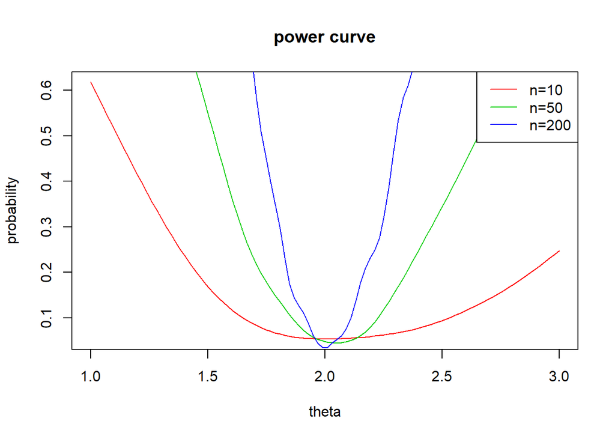

```r
legend("topright",c("n=10","n=50","n=200"),col = c(2,3,4),lty = 1)
```

# Wald Test

Wald Test 的檢定統計量:
$$\chi_w^2\sim[\sqrt{nI_1(\hat\theta)}(\hat\theta-\theta_0)]^2$$
By MLE的大樣本定理:
$$\sqrt{n}(\hat\theta-\theta_0)\stackrel{D}{\to}N(0,\frac{1}{I(\theta_0)})$$
移項後可以得到:
$$\hat\theta\stackrel{D}{\to}N(\theta_0,\frac{1}{nI(\theta_0)})$$
藉由$Z=\frac{x-\mu}{\sigma}$故我們可以得到:
$$Z=\frac{\hat\theta-\theta_0}{\sqrt{\frac{1}{nI_1(\theta_0)}}}$$
再進行平方的話可以得到卡方，可以看出也就是wald test的統計量
$$\chi_w^2\sim[\sqrt{nI_1(\hat\theta)}(\hat\theta-\theta_0)]^2$$

## Normal ditribution N(mu,1)

```r
par(mfrow=c(1,2))
###N(mu,1)###
set.seed(1234)
#set the parameter
B<-100
n<-150
mu<-2
sigma1<-1 #sd

#set the likelihood function and range
L<-function(x_bar, x, sigma0=sigma1) prod( dnorm(x, mean=x_bar, sd=sigma0) ) #Likelihood
theta.hat<-seq(1, 3, length.out = B) #set the range to search MLE
```

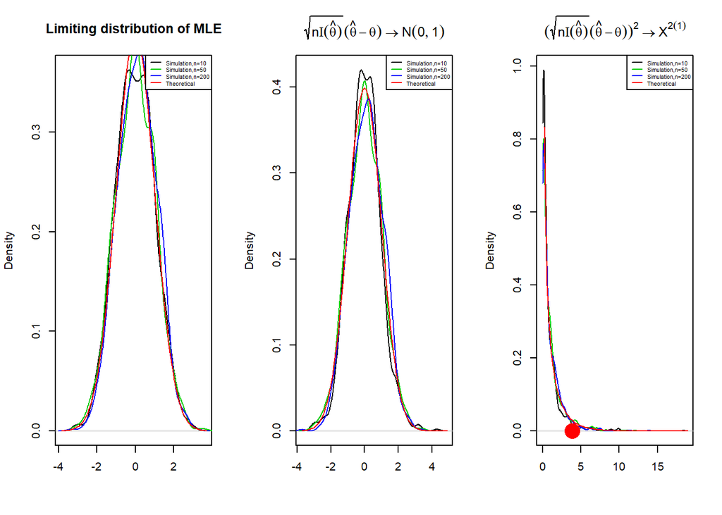

```r
#different sample size
theta.hat<-seq(1, 3, length.out =200)
B<-1000
n1<-10;n2<-50;n3<-200 #sample size
MLE1<-rep(NA,B);MLE2<-rep(NA,B);MLE3<-rep(NA,B)
fisher1<-rep(NA,B);fisher2<-rep(NA,B);fisher3<-rep(NA,B)   #I(theta)=E[((X-theta)/(sigma1^2))^2]
W1<-rep(NA,B);W2<-rep(NA,B);W3<-rep(NA,B)
for (i in 1:B) {
  x1<-rnorm(n1,mean=mu,sd=sigma1)
  x2<-rnorm(n2,mean=mu,sd=sigma1)
  x3<-rnorm(n3,mean=mu,sd=sigma1)
  likehood1<-lapply(theta.hat,function(s) L(x_bar=s,x=x1))
  likehood2<-lapply(theta.hat,function(s) L(x_bar=s,x=x2))
  likehood3<-lapply(theta.hat,function(s) L(x_bar=s,x=x3))
  MLE1[i]<-theta.hat[which.max(likehood1)]             #find MLE
  MLE2[i]<-theta.hat[which.max(likehood2)]
  MLE3[i]<-theta.hat[which.max(likehood3)]
  fisher1[i]<-mean(((x1-MLE1[i])/(sigma1^2))^2) #I(MLE)=E[((X-MLE)/(sigma1^2))^2]
  fisher2[i]<-mean(((x2-MLE2[i])/(sigma1^2))^2)
  fisher3[i]<-mean(((x3-MLE3[i])/(sigma1^2))^2)
}

#3.Limiting dist of MLE.
#different sample size
par(mfrow=c(1,3))
plot(density(sqrt(n1)*(MLE1-mu)),main="Limiting distribution of MLE",xlab="",col=1,cex=1.5)
lines(density(sqrt(n2)*(MLE2-mu)),col=3)
lines(density(sqrt(n3)*(MLE3-mu)),col=4)
curve(dnorm(x,0,sd=sigma1^2),col=2,add=T)      #N(0,1/I(mu=0)=sigma2^2)
legend("topright",c("Simulation,n=10","Simulation,n=50","Simulation,n=200","Theoretical"),lty=1,col=c(1,3,4,2),cex = 0.5)

#4.Transifrom to N(0,1) and Chi-square(1).
Z1<-(sqrt(n1*fisher1)*(MLE1-mu))
Z2<-(sqrt(n2*fisher2)*(MLE2-mu))
Z3<-(sqrt(n3*fisher3)*(MLE3-mu))
plot(density(Z1),main=expression(sqrt(n*Iota(hat(theta)))*(hat(theta)-theta)%->%N(0,1)),xlab="",col=1,cex=1.5)
lines(density(Z2),col=3)
lines(density(Z3),col=4)
curve(dnorm(x,0,1),col=2,add=T)
legend("topright",c("Simulation,n=10","Simulation,n=50","Simulation,n=200","Theoretical"),lty=1,col=c(1,3,4,2),cex = 0.5)

W1<-(sqrt(n1*fisher1)*(MLE1-mu))^2
W2<-(sqrt(n2*fisher2)*(MLE2-mu))^2
W3<-(sqrt(n3*fisher3)*(MLE3-mu))^2
plot(density(W1,from=0),main= expression((sqrt(n*Iota(hat(theta)))*(hat(theta)-theta))^2%->%X^2(1)),xlab="",col=1,cex=1.5)
lines(density(W2,from=0),col=3)
lines(density(W3,from=0),col=4)
curve(dchisq(x,1),col=2,add=T)
points(qchisq(0.95,1), 0, col=2, pch=16, cex=3)
legend("topright",c("Simulation,n=10","Simulation,n=50","Simulation,n=200","Theoretical"),lty=1,col=c(1,3,4,2),cex = 0.5)
```

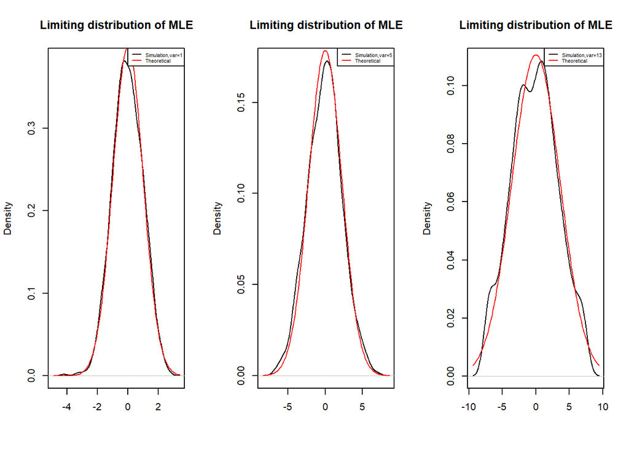

```r
#different variance
theta.hat<-seq(1, 3, length.out =200)
B<-1000
n<-50
var1<-1;var2<-5;var3<-13 #sample variance
MLE1<-rep(NA,B);MLE2<-rep(NA,B);MLE3<-rep(NA,B)
fisher1<-rep(NA,B);fisher2<-rep(NA,B);fisher3<-rep(NA,B)   #I(theta)=E[((X-theta)/(sigma1^2))^2]
W1<-rep(NA,B);W2<-rep(NA,B);W3<-rep(NA,B)
for (i in 1:B) {
  x1<-rnorm(n,mean=mu,sd=sqrt(var1))
  x2<-rnorm(n,mean=mu,sd=sqrt(var2))
  x3<-rnorm(n,mean=mu,sd=sqrt(var3))
  likehood1<-lapply(theta.hat,function(s) L(x_bar=s,x=x1,sigma0=sqrt(var1)))
  likehood2<-lapply(theta.hat,function(s) L(x_bar=s,x=x2,sigma0=sqrt(var2)))
  likehood3<-lapply(theta.hat,function(s) L(x_bar=s,x=x3,sigma0=sqrt(var3)))
  MLE1[i]<-theta.hat[which.max(likehood1)]             #find MLE
  MLE2[i]<-theta.hat[which.max(likehood2)]
  MLE3[i]<-theta.hat[which.max(likehood3)]
  fisher1[i]<-mean(((x1-MLE1[i])/var1)^2)         #I(MLE)=E[((X-MLE)/(sigma1^2))^2]
  fisher2[i]<-mean(((x2-MLE2[i])/var2)^2)
  fisher3[i]<-mean(((x3-MLE3[i])/var3)^2)
}

#3.Limiting dist of MLE.
#different sample size
par(mfrow=c(1,3))
plot(density(sqrt(n)*(MLE1-mu)),main="Limiting distribution of MLE",xlab="",col=1)
curve(dnorm(x,0,sd=sqrt(var1)),col=2,add=T)      #N(0,1/I(mu=0)=sigma2^2)
legend("topright",c("Simulation,var=1","Theoretical"),lty=1,col=c(1,2),cex=0.5)
plot(density(sqrt(n)*(MLE2-mu)),main="Limiting distribution of MLE",xlab="",col=1)
curve(dnorm(x,0,sd=sqrt(var2)),col=2,add=T)      #N(0,1/I(mu=0)=sigma2^2)
legend("topright",c("Simulation,var=5","Theoretical"),lty=1,col=c(1,2),cex=0.5)
plot(density(sqrt(n)*(MLE3-mu)),main="Limiting distribution of MLE",xlab="",col=1)
curve(dnorm(x,0,sd=sqrt(var3)),col=2,add=T)      #N(0,1/I(mu=0)=sigma2^2)
legend("topright",c("Simulation,var=13","Theoretical"),lty=1,col=c(1,2),cex = 0.5)
```

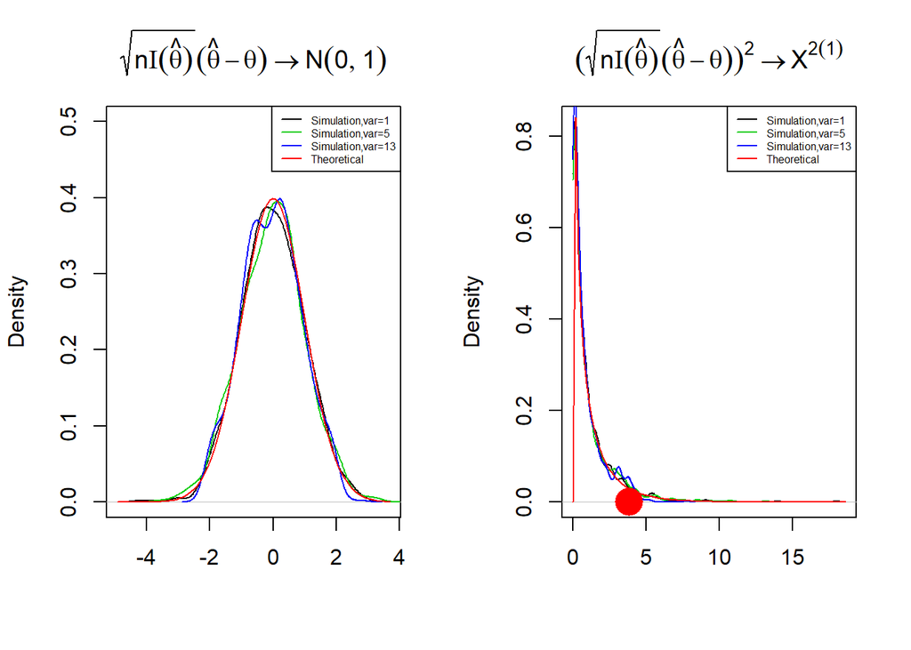

```r
#4.Transifrom to N(0,1) and Chi-square(1).
par(mfrow=c(1,2))
Z1<-(sqrt(n*fisher1)*(MLE1-mu))
Z2<-(sqrt(n*fisher2)*(MLE2-mu))
Z3<-(sqrt(n*fisher3)*(MLE3-mu))
plot(density(Z1),main=expression(sqrt(n*Iota(hat(theta)))*(hat(theta)-theta)%->%N(0,1)),xlab="",col=1,ylim=c(0,0.5))
lines(density(Z2),col=3)
lines(density(Z3),col=4)
curve(dnorm(x,0,1),col=2,add=T)
legend("topright",c("Simulation,var=1","Simulation,var=5","Simulation,var=13","Theoretical"),lty=1,col=c(1,3,4,2),cex=0.5)

W1<-(sqrt(n*fisher1)*(MLE1-mu))^2
W2<-(sqrt(n*fisher2)*(MLE2-mu))^2
W3<-(sqrt(n*fisher3)*(MLE3-mu))^2
plot(density(W1,from=0),main= expression((sqrt(n*Iota(hat(theta)))*(hat(theta)-theta))^2%->%X^2(1)),xlab="",col=1)
lines(density(W2,from=0),col=3)
lines(density(W3,from=0),col=4)
curve(dchisq(x,1),col=2,add=T)
points(qchisq(0.95,1), 0, col=2, pch=16, cex=3)
legend("topright",c("Simulation,var=1","Simulation,var=5","Simulation,var=13","Theoretical"),lty=1,col=c(1,3,4,2),cex=0.5)
```

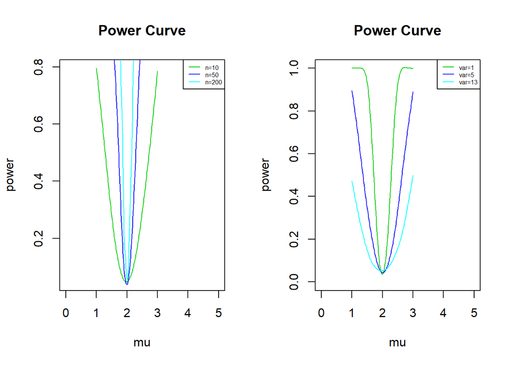

```r
par(mfrow=c(1,2))
#5.Power curve
#diferent sample size
B<-100
n1<-10;n2<-50;n3<-200 #sample size
theta.hat<-seq(1, 3, length.out =100)
W1<-rep(NA,B);W2<-rep(NA,B);W3<-rep(NA,B)
power1<-rep(NA,B);power2<-rep(NA,B);power3<-rep(NA,B)    #p(W>qchisq(0.95,1) | H1)
range<-seq(0, 4, length.out = 2*B)   #range of searching mle
for (j in 1:B){
  H1_mu<-theta.hat[j]
  for (i in 1:B) {
    x1<-rnorm(n1,mean=H1_mu,sd=sigma1)
    x2<-rnorm(n2,mean=H1_mu,sd=sigma1)
    x3<-rnorm(n3,mean=H1_mu,sd=sigma1)
    likehood1<-lapply(range,function(s) L(x_bar=s,x=x1))
    likehood2<-lapply(range,function(s) L(x_bar=s,x=x2))
    likehood3<-lapply(range,function(s) L(x_bar=s,x=x3))
    MLE1<-range[which.max(likehood1)]                     #find MLE
    MLE2<-range[which.max(likehood2)]
    MLE3<-range[which.max(likehood3)]
    fisher1<-mean(((x1-MLE1)/(sigma1^2))^2)        #I(MLE)=E[((X-MLE)/(sigma1^2))^2]
    fisher2<-mean(((x2-MLE2)/(sigma1^2))^2)
    fisher3<-mean(((x3-MLE3)/(sigma1^2))^2)
    W1[i]<-(sqrt(n1*fisher1)*(MLE1-mu))^2
    W2[i]<-(sqrt(n2*fisher2)*(MLE2-mu))^2
    W3[i]<-(sqrt(n3*fisher3)*(MLE3-mu))^2
  }
  power1[j]<-mean(W1>qchisq(0.95,1))
  power2[j]<-mean(W2>qchisq(0.95,1))
  power3[j]<-mean(W3>qchisq(0.95,1))
}
smoothingSpline1 = smooth.spline(theta.hat,power1)
smoothingSpline2 = smooth.spline(theta.hat,power2)
smoothingSpline3 = smooth.spline(theta.hat,power3)
plot(smoothingSpline1,col=3,type='l',main="Power Curve",xlab="mu",ylab="power",xlim=c(0,5))
lines(smoothingSpline2,col=4)
lines(smoothingSpline3,col=5)
legend("topright",c("n=10","n=50","n=200"),lty=1,col=c(3,4,5),cex = 0.5)
wald_power_mu_n1<-smoothingSpline1
wald_power_mu_n2<-smoothingSpline2
wald_power_mu_n3<-smoothingSpline3


#5.Power curve
#diferent sample variance
B<-100
n<-50
var1<-1;var2<-5;var3<-13 #sample variance
theta.hat<-seq(1, 3, length.out =100)
W1<-rep(NA,B);W2<-rep(NA,B);W3<-rep(NA,B)
power1<-rep(NA,B);power2<-rep(NA,B);power3<-rep(NA,B)    #p(W>qchisq(0.95,1) | H1)
range<-seq(0, 4, length.out = 2*B)   #range of searching mle
for (j in 1:B){
  H1_mu<-theta.hat[j]
  for (i in 1:B) {
    x1<-rnorm(n,mean=H1_mu,sd=sqrt(var1))
    x2<-rnorm(n,mean=H1_mu,sd=sqrt(var2))
    x3<-rnorm(n,mean=H1_mu,sd=sqrt(var3))
    likehood1<-lapply(range,function(s) L(x_bar=s,x=x1,sigma0=sqrt(var1)))
    likehood2<-lapply(range,function(s) L(x_bar=s,x=x2,sigma0=sqrt(var2)))
    likehood3<-lapply(range,function(s) L(x_bar=s,x=x3,sigma0=sqrt(var3)))
    MLE1<-range[which.max(likehood1)]                     #find MLE
    MLE2<-range[which.max(likehood2)]
    MLE3<-range[which.max(likehood3)]
    fisher1<-mean(((x1-MLE1)/var1)^2)        #I(MLE)=E[((X-MLE)/(sigma1^2))^2]
    fisher2<-mean(((x2-MLE2)/var2)^2)
    fisher3<-mean(((x3-MLE3)/var3)^2)
    W1[i]<-(sqrt(n*fisher1)*(MLE1-mu))^2
    W2[i]<-(sqrt(n*fisher2)*(MLE2-mu))^2
    W3[i]<-(sqrt(n*fisher3)*(MLE3-mu))^2
  }
  power1[j]<-mean(W1>qchisq(0.95,1))
  power2[j]<-mean(W2>qchisq(0.95,1))
  power3[j]<-mean(W3>qchisq(0.95,1))
}
smoothingSpline1 = smooth.spline(theta.hat,power1)
smoothingSpline2 = smooth.spline(theta.hat,power2)
smoothingSpline3 = smooth.spline(theta.hat,power3)
plot(smoothingSpline1,col=3,type='l',main="Power Curve",xlab="mu",ylab="power",ylim=c(0,1),xlim=c(0,5))
lines(smoothingSpline2,col=4)
lines(smoothingSpline3,col=5)
legend("topright",c("var=1","var=5","var=13"),lty=1,col=c(3,4,5),cex = 0.5)
```

```r
wald_power_mu_var1<-smoothingSpline1
wald_power_mu_var2<-smoothingSpline2
wald_power_mu_var3<-smoothingSpline3
```

## Normal ditribution N(1,sigma2)

```r
###N(1,sigma2)###
#set the parameter
B<-100
n<-150
mu<-1
sigma2<-0.81
#set the likelihood function and range
L<-function(s2, x, mu0=mu) prod(dnorm(x, mean=mu0, sd=sqrt(s2))) #likelyhood of var
theta.hat<-seq(0.1, 1.5, length.out = B) #set the range to search MLE
```

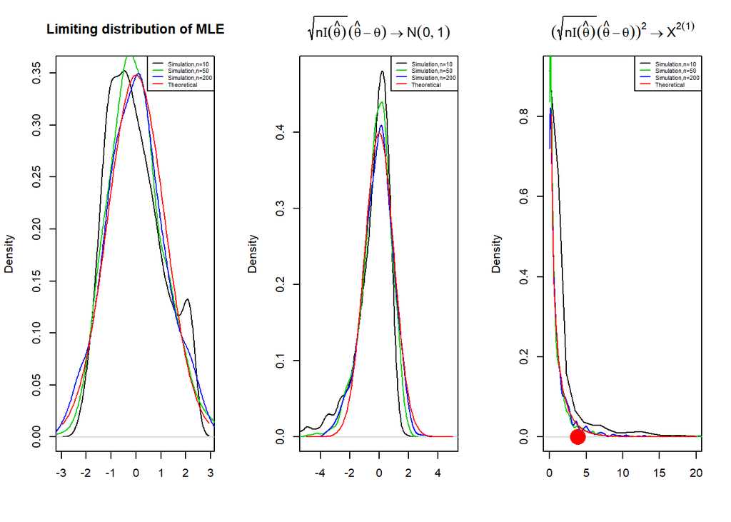

```r
#different sample size
theta.hat<-seq(0, 1.5, length.out =200)
B<-1000
n1<-10;n2<-50;n3<-200 #sample size
MLE1<-rep(NA,B);MLE2<-rep(NA,B);MLE3<-rep(NA,B)
fisher1<-rep(NA,B);fisher2<-rep(NA,B);fisher3<-rep(NA,B)   #I(theta)=E[((X-1)^2/(2*theta)-1/(2*theta))^2]
W1<-rep(NA,B);W2<-rep(NA,B);W3<-rep(NA,B)
for (i in 1:B) {
  x1<-rnorm(n1,mean=mu,sd=sqrt(sigma2))
  x2<-rnorm(n2,mean=mu,sd=sqrt(sigma2))
  x3<-rnorm(n3,mean=mu,sd=sqrt(sigma2))
  likehood1<-lapply(theta.hat,function(s) L(s,x=x1))
  likehood2<-lapply(theta.hat,function(s) L(s,x=x2))
  likehood3<-lapply(theta.hat,function(s) L(s,x=x3))
  MLE1[i]<-theta.hat[which.max(likehood1)]          #find MLE
  MLE2[i]<-theta.hat[which.max(likehood2)]
  MLE3[i]<-theta.hat[which.max(likehood3)]
  fisher1[i]<-mean(((x1-mu)^2/(2*MLE1[i]^2)-1/(2*MLE1[i]))^2)    #I(MLE)=E[((X-1)^2/(2*MLE^2)-1/(2*MLE))^2]
  fisher2[i]<-mean(((x2-mu)^2/(2*MLE2[i]^2)-1/(2*MLE2[i]))^2)
  fisher3[i]<-mean(((x3-mu)^2/(2*MLE3[i]^2)-1/(2*MLE3[i]))^2)
}

#3.Limiting dist of MLE.
#different sample size
par(mfrow=c(1,3))
plot(density(sqrt(n1)*(MLE1-sigma2)),main="Limiting distribution of MLE",xlab="",col=1)
lines(density(sqrt(n2)*(MLE2-sigma2)),col=3)
lines(density(sqrt(n3)*(MLE3-sigma2)),col=4)
curve(dnorm(x,0,sd=sqrt(2*sigma2^2)),col=2,add=T)  #N(0,1/I(sigma^2=1)=2sigma^2)
legend("topright",c("Simulation,n=10","Simulation,n=50","Simulation,n=200","Theoretical"),lty=1,col=c(1,3,4,2),cex = 0.5)

#4.Transifrom to N(0,1) and chi-square.
Z1<-sqrt(n1*fisher1)*(MLE1-sigma2)
Z2<-sqrt(n2*fisher2)*(MLE2-sigma2)
Z3<-sqrt(n3*fisher3)*(MLE3-sigma2)
plot(density(Z1),main=expression(sqrt(n*Iota(hat(theta)))*(hat(theta)-theta)%->%N(0,1)),xlab="",xlim=c(-5,5))
lines(density(Z2),col=3)
lines(density(Z3),col=4)
curve(dnorm(x,0,1),col="red",add=T)
legend("topright",c("Simulation,n=10","Simulation,n=50","Simulation,n=200","Theoretical"),lty=1,col=c(1,3,4,2),cex=0.5)

W1<-(sqrt(n1*fisher1)*(MLE1-sigma2))^2
W2<-(sqrt(n2*fisher2)*(MLE2-sigma2))^2
W3<-(sqrt(n3*fisher3)*(MLE3-sigma2))^2
plot(density(W1,from=0),main= expression((sqrt(n*Iota(hat(theta)))*(hat(theta)-theta))^2%->%X^2(1)),xlab="",col=1,xlim=c(0,20))
lines(density(W2,from=0),col=3)
lines(density(W3,from=0),col=4)
curve(dchisq(x,1),col="red",add=T)
points(qchisq(0.95,1), 0, col=2, pch=16, cex=3)
legend("topright",c("Simulation,n=10","Simulation,n=50","Simulation,n=200","Theoretical"),lty=1,col=c(1,3,4,2),cex = 0.5)
```

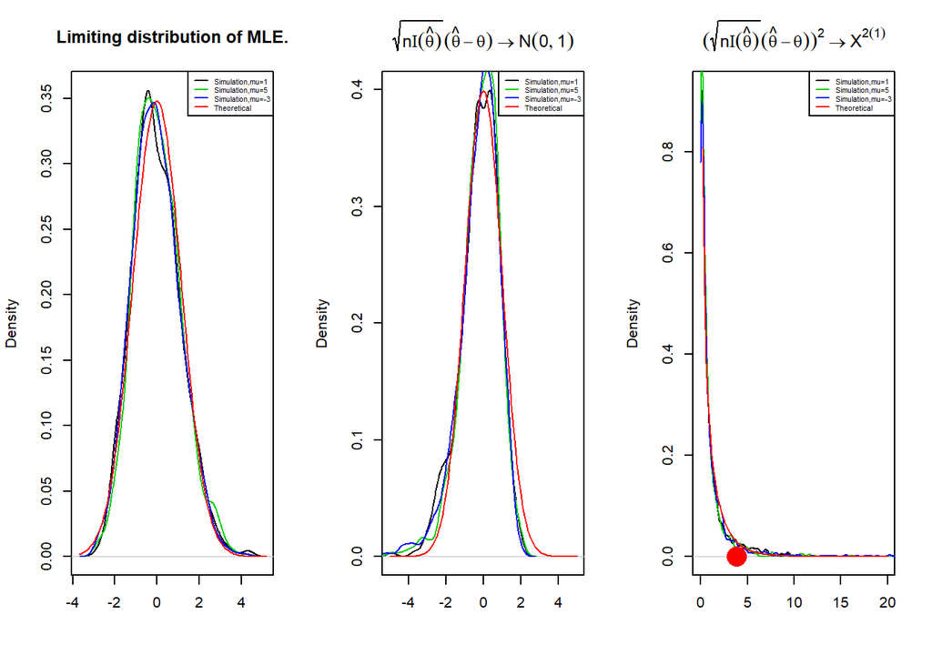

```r
#different mean
theta.hat<-seq(0, 1.5, length.out =200)
B<-1000
n<-50
mu1<-1;mu2<-5;mu3<--3  #mean
MLE1<-rep(NA,B);MLE2<-rep(NA,B);MLE3<-rep(NA,B)
fisher1<-rep(NA,B);fisher2<-rep(NA,B);fisher3<-rep(NA,B)   #I(theta)=E[((X-1)^2/(2*theta)-1/(2*theta))^2]
W1<-rep(NA,B);W2<-rep(NA,B);W3<-rep(NA,B)
for (i in 1:B) {
  x1<-rnorm(n,mean=mu1,sd=sqrt(sigma2))
  x2<-rnorm(n,mean=mu2,sd=sqrt(sigma2))
  x3<-rnorm(n,mean=mu3,sd=sqrt(sigma2))
  likehood1<-lapply(theta.hat,function(s) L(s,x=x1,mu0=mu1))
  likehood2<-lapply(theta.hat,function(s) L(s,x=x2,mu0=mu2))
  likehood3<-lapply(theta.hat,function(s) L(s,x=x3,mu0=mu3))
  MLE1[i]<-theta.hat[which.max(likehood1)]          #find MLE
  MLE2[i]<-theta.hat[which.max(likehood2)]
  MLE3[i]<-theta.hat[which.max(likehood3)]
  fisher1[i]<-mean(((x1-mu1)^2/(2*MLE1[i]^2)-1/(2*MLE1[i]))^2)    #I(MLE)=E[((X-1)^2/(2*MLE^2)-1/(2*MLE))^2]
  fisher2[i]<-mean(((x2-mu2)^2/(2*MLE2[i]^2)-1/(2*MLE2[i]))^2)
  fisher3[i]<-mean(((x3-mu3)^2/(2*MLE3[i]^2)-1/(2*MLE3[i]))^2)
}

#3.Limiting dist of MLE.
#different variance
par(mfrow=c(1,3))
plot(density(sqrt(n)*(MLE1-sigma2)),main="Limiting distribution of MLE.",xlab="",col=1)
lines(density(sqrt(n)*(MLE2-sigma2)),col=3)
lines(density(sqrt(n)*(MLE3-sigma2)),col=4)
curve(dnorm(x,0,sd=sqrt(2*sigma2^2)),col=2,add=T)  #N(0,1/I(sigma^2=1)=2sigma^2)
legend("topright",c("Simulation,mu=1","Simulation,mu=5","Simulation,mu=-3","Theoretical"),lty=1,col=c(1,3,4,2),cex=0.5)

#4.Transifrom to N(0,1) and chi-square.
Z1<-sqrt(n*fisher1)*(MLE1-sigma2)
Z2<-sqrt(n*fisher2)*(MLE2-sigma2)
Z3<-sqrt(n*fisher3)*(MLE3-sigma2)
plot(density(Z1),main=expression(sqrt(n*Iota(hat(theta)))*(hat(theta)-theta)%->%N(0,1)),xlab="",xlim=c(-5,5))
lines(density(Z2),col=3)
lines(density(Z3),col=4)
curve(dnorm(x,0,1),col="red",add=T)
legend("topright",c("Simulation,mu=1","Simulation,mu=5","Simulation,mu=-3","Theoretical"),lty=1,col=c(1,3,4,2),cex = 0.5)

W1<-(sqrt(n*fisher1)*(MLE1-sigma2))^2
W2<-(sqrt(n*fisher2)*(MLE2-sigma2))^2
W3<-(sqrt(n*fisher3)*(MLE3-sigma2))^2
plot(density(W1,from=0),main=expression((sqrt(n*Iota(hat(theta)))*(hat(theta)-theta))^2%->%X^2(1)),xlab="",col=1,xlim=c(0,20))
lines(density(W2,from=0),col=3)
lines(density(W3,from=0),col=4)
curve(dchisq(x,1),col="red",add=T)
points(qchisq(0.95,1), 0, col=2, pch=16, cex=3)
legend("topright",c("Simulation,mu=1","Simulation,mu=5","Simulation,mu=-3","Theoretical"),lty=1,col=c(1,3,4,2),cex = 0.5)
```

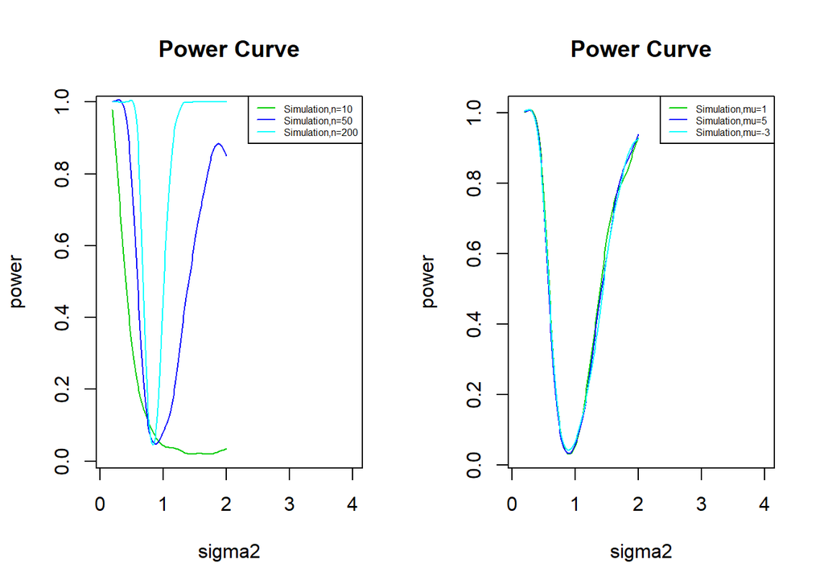

```r
par(mfrow=c(1,2))
#5.Power curve.
#different sample size
B<-100
n1<-10;n2<-50;n3<-200 #sample size
theta.hat<-seq(0.2, 2, length.out =100)
W1<-rep(NA,B);W2<-rep(NA,B);W3<-rep(NA,B)
power1<-rep(NA,B);power2<-rep(NA,B);power3<-rep(NA,B)   #p(W>qchisq(0.95,1) | H1)
range<-seq(0.1, 4, length.out = 2*B)   #range of searching mle
for (j in 1:B){
  H1_sigma<-theta.hat[j]
  for (i in 1:B) {
    x1<-rnorm(n1,mean=mu,sd=sqrt(H1_sigma))
    x2<-rnorm(n2,mean=mu,sd=sqrt(H1_sigma))
    x3<-rnorm(n3,mean=mu,sd=sqrt(H1_sigma))
    likehood1<-lapply(range,function(s2) L(s2,x=x1))
    likehood2<-lapply(range,function(s2) L(s2,x=x2))
    likehood3<-lapply(range,function(s2) L(s2,x=x3))
    MLE1<-range[which.max(likehood1)]               #find MLE
    MLE2<-range[which.max(likehood2)]
    MLE3<-range[which.max(likehood3)]
    fisher1<-mean(((x1-mu)^2/(2*MLE1^2)-1/(2*MLE1))^2) #I(MLE)=E[((X-0)^2/(2*MLE)-1/(2*MLE))^2]
    fisher2<-mean(((x2-mu)^2/(2*MLE2^2)-1/(2*MLE2))^2)
    fisher3<-mean(((x3-mu)^2/(2*MLE3^2)-1/(2*MLE3))^2)
    W1[i]<-(sqrt(n1*fisher1)*(MLE1-sigma2))^2
    W2[i]<-(sqrt(n2*fisher2)*(MLE2-sigma2))^2
    W3[i]<-(sqrt(n3*fisher3)*(MLE3-sigma2))^2
  }
  power1[j]<-mean(W1>qchisq(0.95,1))
  power2[j]<-mean(W2>qchisq(0.95,1))
  power3[j]<-mean(W3>qchisq(0.95,1))
}
smoothingSpline1 = smooth.spline(theta.hat,power1)
smoothingSpline2 = smooth.spline(theta.hat,power2)
smoothingSpline3 = smooth.spline(theta.hat,power3)
plot(smoothingSpline1,col=3,type='l',main="Power Curve",xlab="sigma2",ylab="power",xlim=c(0.1,4))
lines(smoothingSpline2,col=4)
lines(smoothingSpline3,col=5)
legend("topright",c("Simulation,n=10","Simulation,n=50","Simulation,n=200"),lty=1,col=c(3,4,5),cex = 0.5)
wald_power_var_n1<-smoothingSpline1
wald_power_var_n2<-smoothingSpline2
wald_power_var_n3<-smoothingSpline3

#5.Power curve.
#different mean
B<-100
n<-50
mu1<-1;mu2<-5;mu3<--3  #mean
theta.hat<-seq(0.2, 2, length.out =100)
W1<-rep(NA,B);W2<-rep(NA,B);W3<-rep(NA,B)
power1<-rep(NA,B);power2<-rep(NA,B);power3<-rep(NA,B)   #p(W>qchisq(0.95,1) | H1)
range<-seq(0.1, 4, length.out = 2*B)   #range of searching mle
for (j in 1:B){
  H1_sigma<-theta.hat[j]
  for (i in 1:B) {
    x1<-rnorm(n,mean=mu1,sd=sqrt(H1_sigma))
    x2<-rnorm(n,mean=mu2,sd=sqrt(H1_sigma))
    x3<-rnorm(n,mean=mu3,sd=sqrt(H1_sigma))
    likehood1<-lapply(range,function(s2) L(s2,x=x1,mu0=mu1))
    likehood2<-lapply(range,function(s2) L(s2,x=x2,mu0=mu2))
    likehood3<-lapply(range,function(s2) L(s2,x=x3,mu0=mu3))
    MLE1<-range[which.max(likehood1)]               #find MLE
    MLE2<-range[which.max(likehood2)]
    MLE3<-range[which.max(likehood3)]
    fisher1<-mean(((x1-mu1)^2/(2*MLE1^2)-1/(2*MLE1))^2) #I(MLE)=E[((X-mu)^2/(2*MLE)-1/(2*MLE))^2]
    fisher2<-mean(((x2-mu2)^2/(2*MLE2^2)-1/(2*MLE2))^2)
    fisher3<-mean(((x3-mu3)^2/(2*MLE3^2)-1/(2*MLE3))^2)
    W1[i]<-(sqrt(n*fisher1)*(MLE1-sigma2))^2
    W2[i]<-(sqrt(n*fisher2)*(MLE2-sigma2))^2
    W3[i]<-(sqrt(n*fisher3)*(MLE3-sigma2))^2
  }
  power1[j]<-mean(W1>qchisq(0.95,1))
  power2[j]<-mean(W2>qchisq(0.95,1))
  power3[j]<-mean(W3>qchisq(0.95,1))
}
smoothingSpline1 = smooth.spline(theta.hat,power1)
smoothingSpline2 = smooth.spline(theta.hat,power2)
smoothingSpline3 = smooth.spline(theta.hat,power3)
plot(smoothingSpline1,col=3,type='l',main="Power Curve",xlab="sigma2",ylab="power",xlim=c(0.1,4))
lines(smoothingSpline2,col=4)
lines(smoothingSpline3,col=5)
legend("topright",c("Simulation,mu=1","Simulation,mu=5","Simulation,mu=-3"),lty=1,col=c(3,4,5),cex = 0.5)
```

```r
wald_power_var_mean1<-smoothingSpline1
wald_power_var_mean2<-smoothingSpline2
wald_power_var_mean3<-smoothingSpline3
```

## Exponential distribution exp(rate)

```r
par(mfrow=c(2,2))
#set the parameter
B<-100
n<-150
rate<-2
#set the likelihood function and range
L<-function(r, x) prod( dexp(x,rate = r) ) #Likelyhood
theta.hat<-seq(1,3, length.out = B)#set the range to search MLE #rate !
```

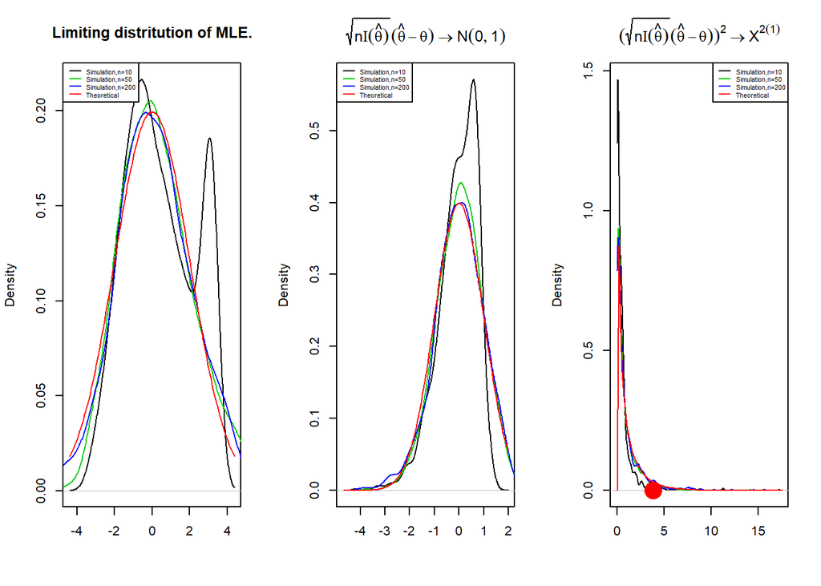

```r
#different sample size
theta.hat<-seq(1, 3, length.out = 100)
B<-1000
n1<-10;n2<-50;n3<-200 #sample size
MLE1<-rep(NA,B);MLE2<-rep(NA,B);MLE3<-rep(NA,B)
fisher1<-rep(NA,B);fisher2<-rep(NA,B);fisher3<-rep(NA,B)   ##I(theta)=E[((-x+1/theta)^2]
W1<-rep(NA,B);W2<-rep(NA,B);W3<-rep(NA,B)
for (i in 1:B) {
  x1<-rexp(n1,rate=rate)
  x2<-rexp(n2,rate=rate)
  x3<-rexp(n3,rate=rate)
  likehood1<-lapply(theta.hat,function(r) L(r,x=x1))
  likehood2<-lapply(theta.hat,function(r) L(r,x=x2))
  likehood3<-lapply(theta.hat,function(r) L(r,x=x3))
  MLE1[i]<-theta.hat[which.max(likehood1)]            #find MLE
  MLE2[i]<-theta.hat[which.max(likehood2)]
  MLE3[i]<-theta.hat[which.max(likehood3)]
  fisher1[i]<-mean((-x1+1/MLE1[i])^2)                  #I(MLE)=E[((-x+1)/MLE)^2]
  fisher2[i]<-mean((-x2+1/MLE2[i])^2)
  fisher3[i]<-mean((-x3+1/MLE3[i])^2)
}
#3.Limiting dist of MLE.
#different sample size
par(mfrow=c(1,3))
plot(density(sqrt(n1)*(MLE1-rate)),main="Limiting distritution of MLE.",xlab="",col=1)
lines(density(sqrt(n2)*(MLE2-rate)),col=3)
lines(density(sqrt(n3)*(MLE3-rate)),col=4)
curve(dnorm(x,0,sd=sqrt(rate^2)),col=2,add=T) #N(0,1/I(rate=1)=rate^2)
legend("topleft",c("Simulation,n=10","Simulation,n=50","Simulation,n=200","Theoretical"),lty=1,col=c(1,3,4,2),cex=0.5)

#4.Transifrom to N(0,1) and Chi-square(1).
Z1<-sqrt(n1*fisher1)*(MLE1-rate)
Z2<-sqrt(n2*fisher2)*(MLE2-rate)
Z3<-sqrt(n3*fisher3)*(MLE3-rate)
plot(density(Z1),xlab="",main=expression(sqrt(n*Iota(hat(theta)))*(hat(theta)-theta)%->%N(0,1)),col=1)
lines(density(Z2),col=3)
lines(density(Z3),col=4)
curve(dnorm(x,0,1),col=2,add=T)
legend("topleft",c("Simulation,n=10","Simulation,n=50","Simulation,n=200","Theoretical"),lty=1,col=c(1,3,4,2),cex=0.5)

W1<-(sqrt(n1*fisher1)*(MLE1-rate))^2
W2<-(sqrt(n2*fisher2)*(MLE2-rate))^2
W3<-(sqrt(n3*fisher3)*(MLE3-rate))^2
plot(density(W1,from=0),xlab="",main=expression((sqrt(n*Iota(hat(theta)))*(hat(theta)-theta))^2%->%X^2(1)),col=1)
lines(density(W2,from=0),col=3)
lines(density(W3,from=0),col=4)
curve(dchisq(x,1),col=2,add=T)
points(qchisq(0.95,1), 0, col=2, pch=16, cex=3)
legend("topright",c("Simulation,n=10","Simulation,n=50","Simulation,n=200","Theoretical"),lty=1,col=c(1,3,4,2),cex = 0.5)
```

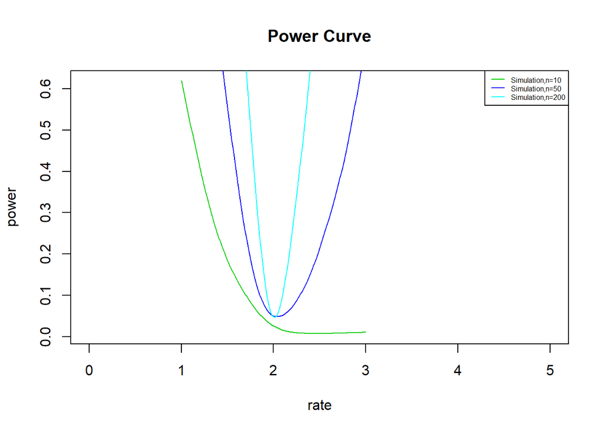

```r
#5.Power curve
B<-100
n1<-10;n2<-50;n3<-200 #sample size
theta.hat<-seq(1, 3, length.out = B)
range<-seq(0.1, 4, length.out = 2*B) #range of searching mle
W1<-rep(NA,B);W2<-rep(NA,B);W3<-rep(NA,B)
power1<-rep(NA,B);power2<-rep(NA,B);power3<-rep(NA,B);  #p(W>qchisq(0.95,1) | H1)
for (j in 1:B){
  H1_rate<-theta.hat[j]
  for (i in 1:B) {
    x1<-rexp(n1,rate=H1_rate)
    x2<-rexp(n2,rate=H1_rate)
    x3<-rexp(n3,rate=H1_rate)
    likehood1<-lapply(range,function(r) L(r,x=x1)) #find MLE
    likehood2<-lapply(range,function(r) L(r,x=x2))
    likehood3<-lapply(range,function(r) L(r,x=x3))
    MLE1<-range[which.max(likehood1)]
    MLE2<-range[which.max(likehood2)]
    MLE3<-range[which.max(likehood3)]
    fisher1<-mean((-x1+1/MLE1)^2)  #I(MLE)=E[((-x+1/MLE)^2]
    fisher2<-mean((-x2+1/MLE2)^2)
    fisher3<-mean((-x3+1/MLE3)^2)
    W1[i]<-(sqrt(n1*fisher1)*(MLE1-rate))^2
    W2[i]<-(sqrt(n2*fisher2)*(MLE2-rate))^2
    W3[i]<-(sqrt(n3*fisher3)*(MLE3-rate))^2
  }
  power1[j]<-mean(W1>qchisq(0.95,1))
  power2[j]<-mean(W2>qchisq(0.95,1))
  power3[j]<-mean(W3>qchisq(0.95,1))
}
smoothingSpline1 = smooth.spline(theta.hat,power1)
smoothingSpline2 = smooth.spline(theta.hat,power2)
smoothingSpline3 = smooth.spline(theta.hat,power3)
plot(smoothingSpline1,col=3,type='l',main="Power Curve",xlab="rate",ylab="power",xlim=c(0,5))
lines(smoothingSpline2,col=4)
lines(smoothingSpline3,col=5)
legend("topright",c("Simulation,n=10","Simulation,n=50","Simulation,n=200"),lty=1,col=c(3,4,5),cex = 0.5)
```

```r
wald_power_rate_n1<-smoothingSpline1
wald_power_rate_n2<-smoothingSpline2
wald_power_rate_n3<-smoothingSpline3
```

# Score Test

Score 檢定的二次近似方程式和 Log Likelihood Ratio 在虛無假設$H_0:\theta=\theta_0$ 時取相同的曲率。所以，Score 檢定使用的近似方程在 $\theta=\theta_0$ 時和 Log Likelihood Ratio 在相同位置時的傾斜度 (一階導數)，和曲率 (坡度的變化程度，二階導數)相同。所以令 $U$ 爲 Log Likelihood Ratio 在 $\theta=\theta_0$時的坡度，定義 $V$ 是 Log Likelihood Ratio 在 $\theta=\theta_0$時的曲率的負數：
$$\begin{aligned}
& U=l'(\theta)|_{\theta=\theta_0}=l'(\theta_0)\\
& V=-E[l''(\theta)]|_{\theta=\theta_0}=-E[l''(\theta_0)]=nI_1(\theta_0)=I_n(\theta_0)
\end{aligned}$$

$$log\Lambda(\theta)\approx q(\theta)=-\frac{1}{2}\bigg(\frac{\hat\theta-\theta}{SD_{\hat\theta}}\bigg)^2\,\text{ asymptotically}$$
則在此即能說明
$$\begin{aligned}
& q^\prime(\theta) =\frac{\hat\theta-\theta}{SD_{\hat\theta}^2}\ \Rightarrow\ q^\prime(\theta_0) =\frac{\hat\theta-\theta_0}{SD_{\hat\theta}^2}\\
\\
& q^{\prime\prime}(\theta) =-\frac{1}{SD_{\hat\theta}^2}\ \Rightarrow \ q^{\prime\prime}(\theta_0)=E[l^{\prime\prime}(\theta_0)]\ \Rightarrow \ \frac{1}{SD_{\hat\theta}^2} =-E[l^{\prime\prime}(\theta_0)]=V\\
\\
& q^\prime(\theta_0) = \frac{\hat\theta-\theta_0}{SD_{\hat\theta}^2} = -E[l^{\prime\prime}(\theta_0)](\hat\theta-\theta_0)\stackrel{P}{\to} l^\prime(\theta_0)\quad\big(\,\text{by Collary 6.2.3 on your textbook !!}\,\big)\\
& \Rightarrow\ \hat\theta-\theta_0 \stackrel{P}{\to} -\frac{l^\prime(\theta_0)}{E[l^{\prime\prime}(\theta_0)]}\ \Rightarrow \ \hat\theta \stackrel{P}{\to} -\frac{l^\prime(\theta_0)}{E[l^{\prime\prime}(\theta_0)]}+\theta_0\\
\\
& q(\theta)=-\frac{1}{2{SD_{\hat\theta}^2}}(\hat\theta-\theta)^2\approx \frac{E[l^{\prime\prime}(\theta_0)]}{2}(-\frac{l^\prime(\theta_0)}{E[l^{\prime\prime}(\theta_0)]}+\theta_0-\theta)^2=-\frac{V}{2}(\frac{U}{V}+\theta_0-\theta)^2
\\
\\
\end{aligned}$$

$$\text{When}\quad\theta\to\theta_0\,,\quad q(\theta_0)\approx -\frac{V}{2}(\frac{U}{V})^2=-\frac{U^2}{2V}
\\$$
因此我們得到 Score Test 的檢定統計量在 $Under\,H_0:\theta=\theta_0$ 時為
$$\chi^2_R=\frac{U^2}{V}=\frac{(l'(\theta_0))^2}{I_n(\theta_0)}\approx -2q(\theta_0) \sim\mathcal{X}_1^2
\\
\\$$
$$\text{Or equivalently},\quad \frac{U}{\sqrt{V}} \sim N(0,1)$$

- Score 檢驗**優點**：
  - 比 LRT 簡單
  - 不需要計算 MLE，只需要計算零假設時的對數似然比方程之坡度和曲率
  - 在流行病學用到的檢驗方法中最常用，也最容易擴展 (Mantel-Haenszel test, log rank test, generalised linear models such as logistic, Poisson, Cox regressions)。
- Score 檢驗**缺點**：
  - 和 Wald 檢驗一樣用到了兩次近似
  - 無法總是保證這是最佳檢驗統計量
  - 參數如果被變數變換， p值會跟着變化。

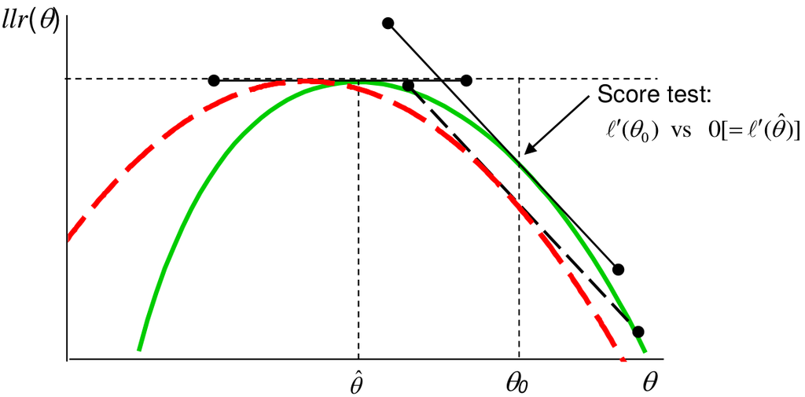

Score 檢定示意圖 https://bookdown.org/ccwang/medical_statistics6/img/Selection_084.png

## RCLB性質之證明

$$which\quad Y=u(X_1,X_2,...,X_n)\,,\quad E(Y)=k(\theta)\quad\big(\,i.e. \text{Y is an unbiased estimator of}\;\theta \,\big)\
\\
\quad k'(\theta)=E(YZ)\,,\quad Z=\frac{\partial}{\partial \theta} logL(X;\theta)$$

以下舉$N(\theta,1)$為例:

$$\hat\theta_{MLE}=\bar{X}=\;\stackrel{\sim}{\theta}=k(\theta)$$

```r
n<-100   # num of random sample
R<-2000   # num of simulation times
B<-1000  # num of possible theta
xx<-seq(-1, 5, length.out = B)
logLf<-function(x,theta) log(prod( dnorm(x,mean=theta,sd=1) ))
rnormdf<-matrix(rnorm(n*R,mean=2,sd=1), n, R)
xa<-rnormdf[,1]
ly<-lydiff<-matrix(NA,R,B)
theta_MLE<-lydiffi<-c()
for(j in 1:R){
  xa<-rnormdf[,j]
  for(i in 1:B){
    ly[j,i]<-logLf(x=xa,theta=xx[i])
  }
  theta_MLE[j]<-xx[which.max(ly[j,])]
  spl <- smooth.spline(ly[j,] ~ xx)
  for(i in 1:B){
    lydiff[j,i] <- predict(spl, x=xx[i], deriv=1)$y
  }
}
#mean(lydiff);0

Y<-colSums(rnormdf)/n  #xbar (n個x_i的總平均)
Z<-rowSums(lydiff)/B
var(Z);100  #In(θ)
```

```
## [1] 98.70951
```

```
## [1] 100
```

```r
ktheta_diff<-mean(Y*Z)
RCLB<-(ktheta_diff^2)/100
RCLB;1/100
```

```
## [1] 0.02235156
```

```
## [1] 0.01
```

```r
var(theta_MLE);1/n
```

```
## [1] 0.009873184
```

```
## [1] 0.01
```

```r
effeciency<-RCLB/var(theta_MLE)
effeciency
```

```
## [1] 2.263866
```

## Normal Distribution N(mu,1)

### 我們知道

$$\hat\theta_{MLE}=\bar{X}$$

我們考慮$n=200$個random sample, $X_1,X_2,...,X_{200}\sim N(\theta,1)$

```r
# N(theta,1)
# Set the parameter
set.seed(123)
n<-200
mu=2
mu1=-0.5
mu2=4.5
sigma2=1
x<-rnorm(n,mean=mu,sd=sigma2) # X1,...,Xn
```

此時我們可以得到最大概似估計量為樣本平均$\hat\theta=\bar{X}\approx1.991$，由於前面已證明，此處不再贅述

```r
# Find  MLE.

B<-10000
Lf<-function(x,theta) prod( dnorm(x,mean=theta,sd=sigma2) ) #likelihood function
theta.hat<-seq(mu1, mu2, length.out = B)

L<-l<-c()
for (i in 1:B){
  #x<-rnorm(n,mean=mean,sd=1)
  L[i]<-Lf(x,theta.hat[i])
  l[i]<-log(L[i])
}
# compare simlution MLE and theretical MLE
theta_MLE=theta.hat[which.max(l)]
theta_MLE;mean(x)
```

```
## [1] 1.991249
```

```
## [1] 1.99143
```

### 以下將以模擬，證明下面兩式

$$I_1(\theta)=E\bigg[\bigg(\frac{\partial logf(X;\theta)}{\partial \theta}\bigg)^2\bigg]=-E\bigg[\frac{\partial^2 logf(X;\theta)}{\partial \theta^2}\bigg]$$
$$E\bigg[\frac{\partial logf(X;\theta)}{\partial \theta}\bigg]=0$$

我們從$n=80$個樣本中取出一個樣本$X_1$，並求其$logf(X;\theta)$，由於每個樣本中有$R=200$個觀測值$x_1,...,x_{200}$，每條線代表固定$x$的情況下，不同$\theta$的$logf(X;\theta)$構成的線，因此會有200條線
$$logf(x;\theta)=-\frac{1}{2}log2\pi-\frac{1}{2}(x-\theta)^2$$

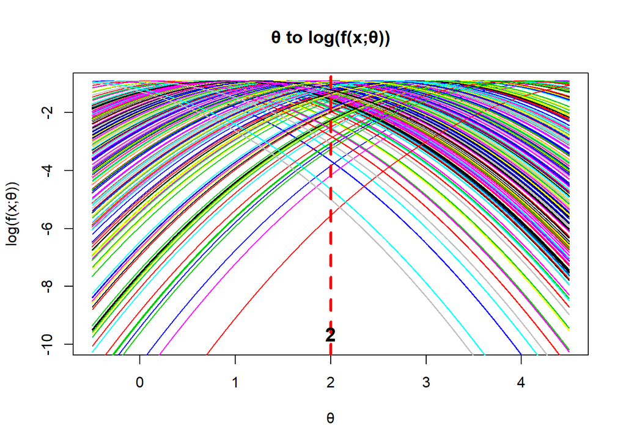

```r
set.seed(1234)
n<-80  # num of samples
R<-200  # simulation times
B<-5000  # num of possible theta
xx<-seq(mu1, mu2, length.out = B)
fy<-matrix(NA,R,B)
rnormf<-rnorm(R,mean=mu,sd=sigma2)  # one sample (X_1) with R observations
for(j in 1:R){
  for(i in 1:B){
    fy[j,i]<-dnorm(x=rnormf[j],mean=xx[i],sd=sigma2,log = TRUE)
  }
  if(j==1){
    plot(xx,fy[1,],xlim=c(mu1,mu2),ylim=c(-10,-1),type = 'l',xlab='θ',ylab = 'log(f(x;θ))',main='θ to log(f(x;θ))')
  }else{
    lines(xx,fy[j,],col=j)
  }
}
abline(v=mu,col=2,lty=2,lwd=3)
text(mu,-10.2, labels=mu, col=1,cex=1.3, font=2,pos=3)
```

我們將$logf(X;\theta)$ 對$\theta$做一次偏微分

$$\frac{\partial}{\partial\theta}logf(\theta)=-\frac{1}{2}\cdot2\cdot(x-\theta)\cdot(-1) =x-\theta$$

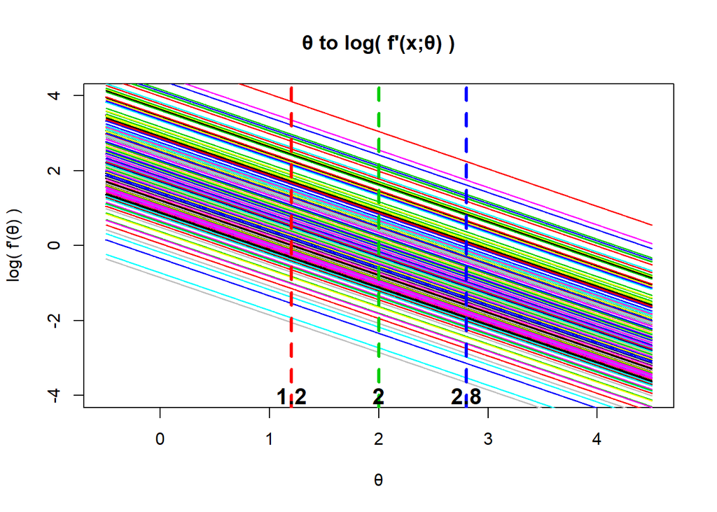

```r
set.seed(1234)
fydiff<-matrix(NA,R,B)
theta2<-c(mu-0.8,mu,mu+0.8)
fydiff2<-c()
for(j in 1:R){
  spl <- smooth.spline(fy[j,] ~ xx)
  for(i in 1:B){
    fydiff[j,i] <- predict(spl, x=xx[i], deriv=1)$y
  }
  if(j==1){
    plot(xx,fydiff[1,],ylim=c(-4,4),type='l',xlab='θ',ylab = 'log( f\'(θ) )',main='θ to log( f\'(x;θ) )')
  }else{
    lines(xx,fydiff[j,],col=j)
  }
  spl2 <- smooth.spline(fydiff[j,] ~ xx)
  fydiff2[j] <- predict(spl2, x=xx[i], deriv=1)$y
}
abline(v=theta2,col=c(2,3,4),lty=2,lwd=3)
text(theta2,-4.5, labels=theta2, col=1,cex=1.3, font=2,pos=3)
```

$$E\bigg[\frac{\partial logf(X;\theta)}{\partial \theta}\bigg]=0$$
記住，在此$\theta$之範圍為$\forall\quad \theta\in\mathbb{R}$，在此情況下，可證得上式

```r
mean((rowSums(fydiff)/B));0
```

```
## [1] -0.05775928
```

```
## [1] 0
```

$$I_1(\theta)=E\bigg[\bigg(\frac{\partial logf(X;\theta)}{\partial \theta}\bigg)^2\bigg]=-E\bigg[\frac{\partial^2 logf(X;\theta)}{\partial \theta^2}\bigg]=-E\bigg[\frac{\partial}{\partial\theta}(x-\theta)\bigg]=1$$

```r
mean((rowSums(fydiff)/B)^2);1
```

```
## [1] 1.039887
```

```
## [1] 1
```

```r
mean(fydiff2)*-1;1
```

```
## [1] 1
```

```
## [1] 1
```

### 以下將針對不同的

$\theta_0,\theta_1,\theta_2,...,\theta_i,...$證明
$$E\bigg[\frac{\partial}{\partial\theta}logf(\theta)_{|\theta=\theta_0}\bigg]=0$$

我們取$θ$範圍內的三個值，包含$θ_0=2$，畫出這三個$θ$下的$\frac{\partial}{\partial\theta}logf(\theta)$之Probability Density Plot

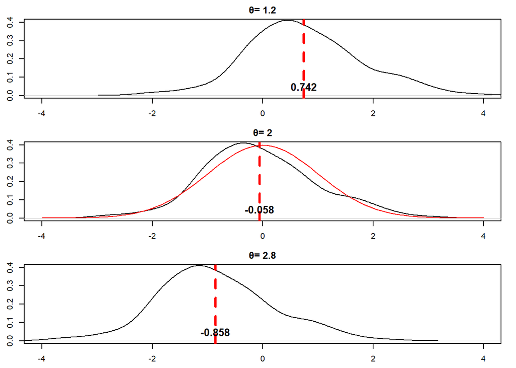

```r
set.seed(1234)
fydifftheta<-matrix(NA,length(theta2),R)
for(k in 1:length(theta2)){
  for(j in 1:R){
    spl <- smooth.spline(fy[j,] ~ xx)
    fydifftheta[k,j]<-predict(spl, x=theta2[k], deriv=1)$y
  }
}
par(mfrow=c(3,1),mar=c(2.5,2.5,2,1.5))
plot(density(fydifftheta[1,]),xlim=c(-4,4),ylim=c(0,0.4),main = paste("θ=",theta2[1]),xlab = '')
abline(v=mean(fydifftheta[1,]),col=2,lty=2,lwd=3)
text(mean(fydifftheta[1,]),0, labels=round(mean(fydifftheta[1,]),3), col=1,cex=1.3, font=2,pos=3)
#curve(dnorm(x,mean=mean(fydifftheta[1,])),col=2,add=T)
plot(density(fydifftheta[2,]),xlim=c(-4,4),ylim=c(0,0.4),main = paste("θ=",theta2[2]),xlab = '')
curve(dnorm(x,mean=0),col=2,add=T)
abline(v=mean(fydifftheta[2,]),col=2,lty=2,lwd=3)
text(mean(fydifftheta[2,]),0, labels=round(mean(fydifftheta[2,]),3), col=1,cex=1.3, font=2,pos=3)
plot(density(fydifftheta[3,]),xlim=c(-4,4),ylim=c(0,0.4),main = paste("θ=",theta2[3]),xlab = '')
abline(v=mean(fydifftheta[3,]),col=2,lty=2,lwd=3)
text(mean(fydifftheta[3,]),0, labels=round(mean(fydifftheta[3,]),3), col=1,cex=1.3, font=2,pos=3)
```

### 檢定

透過n個樣本，再次證明
$$\hat\theta_{MLE}=\bar{X}$$

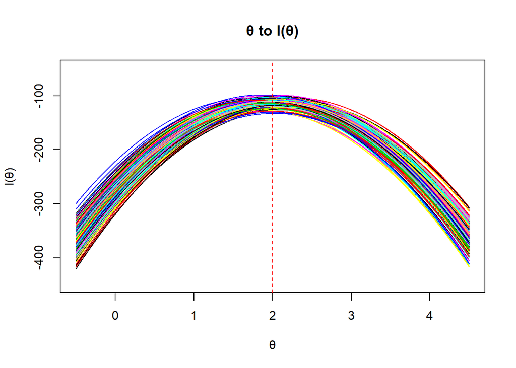

```r
set.seed(12345)
logLf<-function(x,theta) log(prod( dnorm(x,mean=theta,sd=sigma2) ))
rnormdf<-matrix(rnorm(n*R,mean=mu,sd=sigma2), n, R)
xa<-rnormdf[,1]
ly<-matrix(NA,R,B)
theta_MLE<-c()
for(j in 1:R){
  xa<-rnormdf[,j]
  for(i in 1:B){
    ly[j,i]<-logLf(x=xa,theta=xx[i])
  }
  if(j==1){
    plot(xx,ly[1,],xlim=c(mu1,mu2),ylim=c(-450,-50),type = 'l',xlab='θ',ylab = 'l(θ)',main='θ to l(θ)')
  }else{
    lines(xx,ly[j,],col=j)
  }
  theta_MLE[j]<-xx[which.max(ly[j,])]
}
abline(v=mu,col=2,lty=2)
```

```r
mean(theta_MLE);mean(rnormdf)  #theta_MLE=xbar
```

```
## [1] 1.998825
```

```
## [1] 1.998818
```

```r
var(theta_MLE);sigma2/n  #variance of xbar
```

```
## [1] 0.01155422
```

```
## [1] 0.0125
```

$$E\bigg[\frac{\partial}{\partial \theta} logL(X;\theta)\bigg]=E\bigg[\frac{\partial }{\partial \theta}\sum^{n}_{i=1} logf(x_i;\theta)\bigg]=\sum^{n}_{i=1}E\bigg[\frac{\partial }{\partial \theta} logf(x_i;\theta)\bigg]=0$$

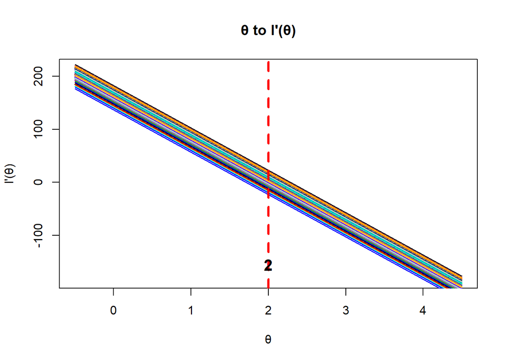

```r
lydiff<-matrix(NA,R,B)
lydiff2<-c()
for(j in 1:R){
  spl <- smooth.spline(ly[j,] ~ xx)
  for(i in 1:B){
    lydiff[j,i] <- predict(spl, x=xx[i], deriv=1)$y
  }
  if(j==1){
    plot(xx,lydiff[1,],type='l',xlab='θ',ylab = 'l\'(θ)',main='θ to l\'(θ)')
  }else{
    lines(xx,lydiff[j,],col=j)
  }
  spl2 <- smooth.spline(lydiff[j,] ~ xx)
  lydiff2[j] <- predict(spl2, x=xx[i], deriv=1)$y
}
abline(v=mu,col=2,lty=2,lwd=3)
text(mu,-180, labels=mu, col=1,cex=1.3, font=2,pos=3)
```

```r
lydiffi<-rowSums(lydiff)/B
mean(lydiffi);0
```

```
## [1] -0.09453636
```

```
## [1] 0
```

$$I_n(\theta)=E\bigg[\bigg(\frac{\partial}{\partial \theta} logL(X;\theta)\bigg)^2\bigg]=E\bigg[\bigg(\frac{\partial }{\partial \theta}\sum^{n}_{i=1} logf(x_i;\theta)\bigg)^2\bigg]\dots\text{equation 1}
\\=
E\bigg[\sum^{n}_{i=1}\bigg(\frac{\partial }{\partial \theta} logf(x_i;\theta)\bigg)^2+\sum_{i\not=j}\frac{\partial }{\partial \theta}logf(x_i;\theta)\frac{\partial }{\partial \theta}logf(x_j;\theta)\bigg]
\\=
\sum^{n}_{i=1}E\bigg[\bigg(\frac{\partial }{\partial \theta} logf(x_i;\theta)\bigg)^2\bigg]+\sum_{i\not=j}\bigg\{E\bigg[\frac{\partial }{\partial \theta}logf(x_i;\theta)\bigg]E\bigg[\frac{\partial }{\partial \theta}logf(x_j;\theta)\bigg]\bigg\}
\\=\sum^{n}_{i=1}E\bigg[\bigg(\frac{\partial }{\partial \theta} logf(x_i;\theta)\bigg)^2\bigg]=nI_1(\theta)\dots\text{equation 2}$$

```r
mean(lydiffi^2);var(lydiffi);n*-mean(fydiff2) #In(θ)
```

```
## [1] 73.60455
```

```
## [1] 73.96544
```

```
## [1] 80
```

```r
I1<-mean(fydiff2)*-1 #I1(θ)
In<-n*I1
In
```

```
## [1] 80
```